# Medellin neighborhood clustering given accidents analytics

Alejandro Cadavid Romero

Universidad Nacional de Colombia  
alcadavidro@unal.edu.co

Santiago Vasquez Rodriguez

Universidad Nacional de Colombia  
svasquezro@unal.edu.co

# Introducción

Este documento hace parte del trabajo del curso de **Analítica Predictiva** de la Universidad Nacional de Colombia para la Maestría en Ingeniería y Especialización en Analítica. El alcance de este es la agrupación de los barrios de Medellín de acuerdo a su accidentalidad, para esto, se llevara a cabo un análisis exploratorio a nivel de barrios para determinar las variables que mejor se pueden ajustar a un algoritmo de agrupación o clustering. Como resultado, se presentaran los grupos en un mapa y se discutiran las características espaciales de dichos grupos.

### Carga de librerias

```r
# Manipulación de datos
library(dplyr)
library(tidyr)
library(lubridate)
library(na.tools)
library(factoextra)
```

```r
library(clustertend)

# Análisis geoespacial
library(geosphere)
library(leaflet)

# Visualización
library(ggplot2)

# Formato tablas
library(kableExtra)
```

### Carga de datos y vistazo inicial

```r
df <- rbind(
  read.csv('../../data/processed/train_data.csv'),
  read.csv('../../data/processed/test_data.csv')
  )
kable(head(df)) %>%
  kable_styling(bootstrap_options = "striped", full_width = F) %>%
  scroll_box(width = "100%")
```

| X | DIA | PERIODO | CLASE | DIRECCION | DIRECCION_ENC | CBML | TIPO_GEOCOD | GRAVEDAD | BARRIO | COMUNA | DISENO | DIA_NOMBRE | MES | LONGITUD | LATITUD | FECHA |
| --- | --- | --- | --- | --- | --- | --- | --- | --- | --- | --- | --- | --- | --- | --- | --- | --- |
| 1 | 1 | 2014 | choque | cr 63 cl 94 | cr 063 094 000 00000 |  | no ubicada | solo danos |  |  | tramo de via | miercoles | 1 | -75.70382 | 6.221806 | 2014-01-01 19:00:00 |
| 2 | 1 | 2014 | choque | cl 30 cr 66 b | cl 030 066 b 000 00000 | 1602 | malla vial | solo danos | rosales | belen | interseccion | miercoles | 1 | -75.58727 | 6.231716 | 2014-01-01 07:40:00 |
| 3 | 1 | 2014 | choque | cr 52 cl 97 | cr 052 097 000 00000 | 0402 | malla vial | solo danos | san isidro | aranjuez | interseccion | miercoles | 1 | -75.56253 | 6.289907 | 2014-01-01 05:30:00 |
| 4 | 1 | 2014 | choque | tv 78 cl 65 | tv 078 065 000 00000 | 0519 | malla vial | solo danos | el progreso | castilla | tramo de via | miercoles | 1 | -75.57365 | 6.275473 | 2014-01-01 13:50:00 |
| 5 | 1 | 2014 | otro | cr 63 cl 50 | cr 063 050 000 00000 | 1101 | malla vial | solo danos | carlos e. restrepo | laureles estadio | tramo de via | miercoles | 1 | -75.57697 | 6.255457 | 2014-01-01 07:25:00 |
| 6 | 1 | 2014 | choque | cr 57 cl 51 | cr 057 051 000 00000 | 1006 | malla vial | solo danos | san benito | la candelaria | tramo de via | miercoles | 1 | -75.57481 | 6.254322 | 2014-01-01 04:15:00 |

### Vista de los tipos de los datos y características inicales

```r
str(df)
```

```
## 'data.frame':    228693 obs. of  17 variables:
##  $ X            : int  1 2 3 4 5 6 7 8 9 10 ...
##  $ DIA          : int  1 1 1 1 1 1 1 1 1 1 ...
##  $ PERIODO      : int  2014 2014 2014 2014 2014 2014 2014 2014 2014 2014 ...
##  $ CLASE        : chr  "choque" "choque" "choque" "choque" ...
##  $ DIRECCION    : chr  "cr 63 cl 94" "cl 30 cr 66 b" "cr 52 cl 97" "tv 78 cl 65" ...
##  $ DIRECCION_ENC: chr  "cr  063   094  000 00000" "cl  030   066 b  000 00000" "cr  052   097  000 00000" "tv  078   065  000 00000" ...
##  $ CBML         : chr  "" "1602" "0402" "0519" ...
##  $ TIPO_GEOCOD  : chr  "no ubicada" "malla vial" "malla vial" "malla vial" ...
##  $ GRAVEDAD     : chr  "solo danos" "solo danos" "solo danos" "solo danos" ...
##  $ BARRIO       : chr  "" "rosales" "san isidro" "el progreso" ...
##  $ COMUNA       : chr  "" "belen" "aranjuez" "castilla" ...
##  $ DISENO       : chr  "tramo de via" "interseccion" "interseccion" "tramo de via" ...
##  $ DIA_NOMBRE   : chr  "miercoles" "miercoles" "miercoles" "miercoles" ...
##  $ MES          : int  1 1 1 1 1 1 1 1 1 1 ...
##  $ LONGITUD     : num  -75.7 -75.6 -75.6 -75.6 -75.6 ...
##  $ LATITUD      : num  6.22 6.23 6.29 6.28 6.26 ...
##  $ FECHA        : chr  "2014-01-01 19:00:00" "2014-01-01 07:40:00" "2014-01-01 05:30:00" "2014-01-01 13:50:00" ...
```

### Transformación de tipos de datos

Inicialmente, se transforman los datos de tipo fecha, ya que son una gran fuente de información al momento de crear nuevas variables, como estadísticos agregados de las clases de accidentes y extracción de características espaciales.

```r
df <- df %>%
  mutate(
    FECHA=lubridate::as_datetime(FECHA)
    ) %>%
  mutate(
    SEMANA=lubridate::week(FECHA),
    HORA=lubridate::hour(FECHA)
  )
```

```r
df %>%
  group_by(BARRIO) %>%
  summarise(
    Frecuencia=n(),
    prop=round(n()/nrow(df), 3),
    .groups="drop") %>%
  arrange(desc(Frecuencia), .by_group=T) %>%
  top_n(10) %>%
  kable() %>% kable_styling(bootstrap_options = "striped", position = "left")
```

| BARRIO | Frecuencia | prop |
| --- | --- | --- |
|  | 19766 | 0.086 |
| la candelaria | 5101 | 0.022 |
| caribe | 4436 | 0.019 |
| campo amor | 4147 | 0.018 |
| perpetuo socorro | 4122 | 0.018 |
| los conquistadores | 3756 | 0.016 |
| barrio colon | 3630 | 0.016 |
| guayaquil | 3513 | 0.015 |
| san benito | 3437 | 0.015 |
| santa fe | 3376 | 0.015 |

Como se puede observar, 19766 observaciones, que corresponden a casi un 10% de los datos, no tienen **barrio** asociado. Siendo una cantidad imporante de los datos, se va a proceder a realizar una imputación por distancia acorde a la latitud y longitud de esos registros vs los centroides de estás dos variables de los registros que si poseen información. Antes de proceder, se valida la completitud de las columnas de latitud y longitud de los datos.

```r
rbind(df %>%
        dplyr::select(LATITUD, LONGITUD) %>%
        summarise(
          na_values=sum(is.na(LATITUD)),
          avg=round(mean(LATITUD),5),
          std=round(sd(LATITUD),5),
          min_value=round(min(LATITUD),5),
          max_value=round(max(LATITUD),5),
          .groups="drop"
          ),
      df %>%
        dplyr::select(LATITUD, LONGITUD) %>%
        summarise(
          na_values=sum(is.na(LONGITUD)),
          avg=round(mean(LONGITUD),5),
          std=round(sd(LONGITUD),5),
          min_value=round(min(LONGITUD),5),
          max_value=round(max(LONGITUD),5),
          .groups="drop"
          )
    ) %>%
  t() %>% data.frame() %>%
  rename(LATITUD=X1, LONGITUD=X2) %>%
  kable() %>% kable_styling(bootstrap_options = "striped", position = "left")
```

|  | LATITUD | LONGITUD |
| --- | --- | --- |
| na_values | 0.00000 | 0.00000 |
| avg | 6.24840 | -75.58750 |
| std | 0.02787 | 0.03950 |
| min_value | 6.15193 | -75.70382 |
| max_value | 6.34341 | -75.47344 |

### Centroides de los barrios conocidos

Como se puede observar, no hay valores extremos o atípicos dentro de la longitud y latitud, al igual que no hay valores nulos por lo que se puede proceder con la estrategia planteada de extraer el centroide de cada barrio de acuerdo a los accidentes, e imputar los valores de los barrios de acuerdo a la cercania del registro del accidente con los centroides de los barrios. Para esto, se usara la distancia de harvesine entre dos puntos.

```r
centroides_barrios <- df %>%
  dplyr::select(BARRIO, LATITUD, LONGITUD) %>%
  filter(!(BARRIO %in% c("", "0", "6001", "7001", "9004", "", "9086"))) %>%
  group_by(BARRIO) %>%
  summarise(
    n_accidentes=n(),
    lng=median(LONGITUD),
    lat=median(LATITUD),
    .groups="drop_last"
    ) %>%
  arrange(desc(n_accidentes))

centroides_barrios %>% top_n(15, n_accidentes) %>% kable() %>% kable_styling(bootstrap_options = "striped", position = "left")
```

| BARRIO | n_accidentes | lng | lat |
| --- | --- | --- | --- |
| la candelaria | 5101 | -75.56578 | 6.248704 |
| caribe | 4436 | -75.57446 | 6.268025 |
| campo amor | 4147 | -75.58192 | 6.214046 |
| perpetuo socorro | 4122 | -75.57427 | 6.233385 |
| los conquistadores | 3756 | -75.58306 | 6.240020 |
| barrio colon | 3630 | -75.56921 | 6.243275 |
| guayaquil | 3513 | -75.57357 | 6.246122 |
| san benito | 3437 | -75.57384 | 6.253888 |
| santa fe | 3376 | -75.57825 | 6.223634 |
| carlos e. restrepo | 2987 | -75.58015 | 6.256308 |
| villa nueva | 2908 | -75.56299 | 6.253410 |
| terminal de transporte | 2906 | -75.57280 | 6.276299 |
| san diego | 2860 | -75.56941 | 6.233526 |
| naranjal | 2709 | -75.58253 | 6.248620 |
| castilla | 2599 | -75.57047 | 6.289639 |

Vamos a visualizar los centroides de los barrios de acuerdo a los registros de los accidentes..

```r
centroides_barrios %>%
  leaflet() %>%
  addTiles() %>%
  addMarkers(
    clusterOptions = markerClusterOptions(),
  ) %>%
  setView(lng = mean(centroides_barrios$lng), lat = mean(centroides_barrios$lat), zoom = 11)
```

```
## Assuming "lng" and "lat" are longitude and latitude, respectively
```

[interactive chart not shown]

Lo primero que se observa en los centroides de los barrios, es que hay 3 barrios, específicamente los cercanos a san feliz y otros hacia el oriente del área metropolitana que se encuentran muy lejos de la densidad de accidentes. Por otro lado hay otros 14 barrios cercanos a San Antonio de Prado, lo cual ya se encuentra cerca del borde del área metropolitana, con lo cual nos cuestina si es necesario incluir estos barrios.

Ahora teniendo la tabla de referencia de la latitud y la longitud para los barrios conocidos, se usa la fórmula del semiverseno para calcular la distancia espacial entre los centroides de los barrios conocidos y las coordenadas de los registros que no se tiene un barrio. Una vez computada estás distancias, se toma las coordenadas con menor distancia y se asigna ese barrio.

```r
asignacion_barrios <- function(df_barrios, centroides_referencia){
  barrios <- c()
  for (i in 1:nrow(df_barrios)){
    idx <- which.min(distHaversine(
      p1 = df_barrios[i, ],
      p2 = centroides_referencia[,c(3, 4)])
      )
    barrio <- centroides_referencia[idx, 1] %>% unlist(., use.names = F)
    barrios[i] <- barrio
  }
  return(barrios)
}

df_con_barrio <- df %>%
  filter(!(BARRIO %in% c("", "0", "6001", "7001", "9004", "", "9086")))

df_sin_barrio <- df %>%
  filter(BARRIO %in% c("", "0", "6001", "7001", "9004", "", "9086"))

df_lng_lat <- df_sin_barrio %>%
  dplyr::select(LONGITUD, LATITUD)


centroides_barrios <- as.data.frame(centroides_barrios)
df_lng_lat <- as.data.frame(df_lng_lat)

barrios <- asignacion_barrios(df_barrios = df_lng_lat, centroides_referencia = centroides_barrios)

df_sin_barrio$BARRIO <- barrios

# df <- rbind(df_sin_barrio, df_con_barrio)
```

```r
df_sin_barrio %>%
  group_by(BARRIO) %>%
  summarise(
    n_records=n(),
    proportion=(n()  / nrow(df_sin_barrio))*100,
    .groups="drop_last"
  ) %>%
  arrange(desc(n_records)) %>%
  top_n(10) %>% kable() %>% kable_styling(bootstrap_options = "striped", position = "left")
```

| BARRIO | n_records | proportion |
| --- | --- | --- |
| la oculta | 19251 | 97.1046658 |
| la aguacatala | 224 | 1.1298865 |
| suburbano chacaltaya | 139 | 0.7011349 |
| media luna | 37 | 0.1866330 |
| auc1 | 28 | 0.1412358 |
| piedras blancas represa | 19 | 0.0958386 |
| alejandro echavarria | 12 | 0.0605296 |
| suburbano el llano | 12 | 0.0605296 |
| eduardo santos | 9 | 0.0453972 |
| los cerros el vergel | 8 | 0.0403531 |
| ocho de marzo | 8 | 0.0403531 |

La mayoria de las asignaciones corresponde al barrio **la oculta** (aproximadamente el 97%), el cual es un barrio de **San Antonio de Prado**. Sin embargo, sería interesante revisar cual es la ubicación promedio de estos registros que se les acaba de imputar el barrio.

```r
coordinates <- df_sin_barrio %>%
  summarise(
    mean_lat=mean(LATITUD),
    mean_lng=mean(LONGITUD),
    max_lat=max(LATITUD),
    max_lng=max(LONGITUD),
    min_lat=min(LATITUD),
    min_lng=min(LONGITUD)
  )

leaflet() %>%
  setView(lng = mean(df_con_barrio$LONGITUD), lat = mean(df_con_barrio$LATITUD), zoom= 11) %>%
  addMarkers(
    lng = coordinates$mean_lng,
    lat = coordinates$mean_lat,
    label = "Media lat-lng de registros sin barrio",
    labelOptions = labelOptions(noHide = T, direction = "bottom", textOnly = T, style = list("font-size" = "13px", "font-weight" = "bold"))
    ) %>%
  addTiles()
```

[interactive chart not shown]

Como se puede ver, el promedio de la latitudy la longitud es a las afueras de medellín, a las afueras de san antonio de prado, por esto, aproximadamente el 97% de la imputación de los datos, se hace con el barrio **la oculta**. Por calidad del análisis está imputación está altamente sesgada por la zona de los accidentes, lo cual consideramos innecesario proceder con los barrios imputados con la oculta, con lo que se va a proceder a dejar la imputación para el 3% restante

```r
df <- rbind(
  df_con_barrio,
  rbind(df_sin_barrio %>%
          filter(BARRIO=="la oculta") %>%
          mutate(BARRIO=""),
        df_sin_barrio %>%
          filter(BARRIO!="la oculta")
  )
)
```

### Centroides de las comunas conocidas

Después del [análisis exploratorio de datos](https://www.google.com), se evidenció que el problema de los barrios se extiende de igual forma a las comunas, pero viendo el mapa anterior donde el promedio de estos registros se encuentran en las afueras del área metropolitana, no es de extrañarse que estos faltantes o registros nulos se refieran al mismo caso. Sin embargo, hubo un porcentaje pequeño que si podía registrarse en el área, como fue el caso del 1.2% del subconjunto de datos (registros sin barrio). Volvemos a repetir los mismos pasos anteriores para hacer imputación, sin embargo, antes vamos a visualizar el promedio de la latitud y longitud y ubicarlo en un mapa.

```r
rbind(df %>%
        group_by(COMUNA) %>%
        summarise(
          n_values = n(),
          .groups = "drop"
        ) %>%
        arrange(n_values) %>% top_n(5),
      df %>%
        group_by(COMUNA) %>%
        summarise(
          n_values = n(),
          .groups = "drop"
        ) %>%
        arrange(n_values) %>% slice(1:5)) %>%
  kable() %>% kable_styling(bootstrap_options = "striped", position = "left")
```

| COMUNA | n_values |
| --- | --- |
| el poblado | 17149 |
|  | 19736 |
| castilla | 21209 |
| laureles estadio | 23850 |
| la candelaria | 43715 |
| alejandro echavarria | 1 |
| alfonso lopez | 1 |
| altavista | 1 |
| antonio narino | 1 |
| barrio colon | 1 |

```r
coordinates <- df %>%
  filter(COMUNA == "") %>%
  summarise(
    mean_lat=mean(LATITUD),
    mean_lng=mean(LONGITUD),
    max_lat=max(LATITUD),
    max_lng=max(LONGITUD),
    min_lat=min(LATITUD),
    min_lng=min(LONGITUD)
  )

leaflet() %>%
  setView(lng = mean(df_con_barrio$LONGITUD), lat = mean(df_con_barrio$LATITUD), zoom= 11) %>%
  addMarkers(
    lng = coordinates$mean_lng,
    lat = coordinates$mean_lat,
    label = "Media lat-lng de registros sin comuna",
    labelOptions = labelOptions(noHide = T, direction = "bottom", textOnly = T, style = list("font-size" = "13px", "font-weight" = "bold"))
    ) %>%
  addTiles()
```

[interactive chart not shown]

Se evidencia la falta de comuna para estos registros y que el centroide de lat-lng es el mismo, debido a que la clusterización se va hacer a nivel de barrio, se va dejar este campo vacio para los registros que no se tienen datos

## Clustering de barrios de acuerdo a la accidentalidad

Antes de proceder a realizar el agrupamiento de los barrios en función de la accidentalidad, se debe hacer una exploración rápida de los accidentes en función del tiempo, para validar si el agrupamiento se debe hacer también en función del tiempo, como el año, o sobre todo el conjunto de datos sin discriminar el tiempo.

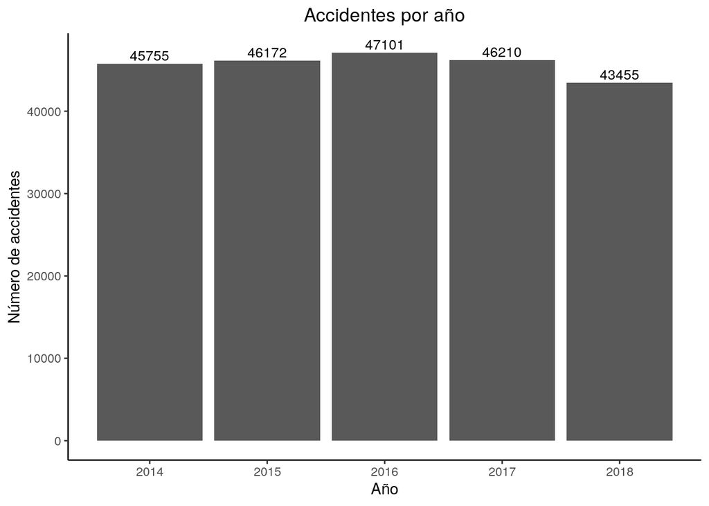

```r
df %>%
  group_by(PERIODO) %>%
  summarise(
    n_accidentes=n(),
    .groups="drop"
  ) %>%
  ggplot() +
  geom_bar(aes(x=PERIODO, y=n_accidentes), stat = "identity") +
  labs(x="Año", y ="Número de accidentes") +
  ggtitle("Accidentes por año") +
  geom_text(aes(x=PERIODO, y=n_accidentes,label = n_accidentes), vjust=-0.3, size=3.5) +
  theme_classic() +
  theme(plot.title = element_text(hjust = 0.5))
```

Como se ve en el anterior gráfico, el número de accidentes por año es muy *estable* a lo largo de los 5 años del análisis.

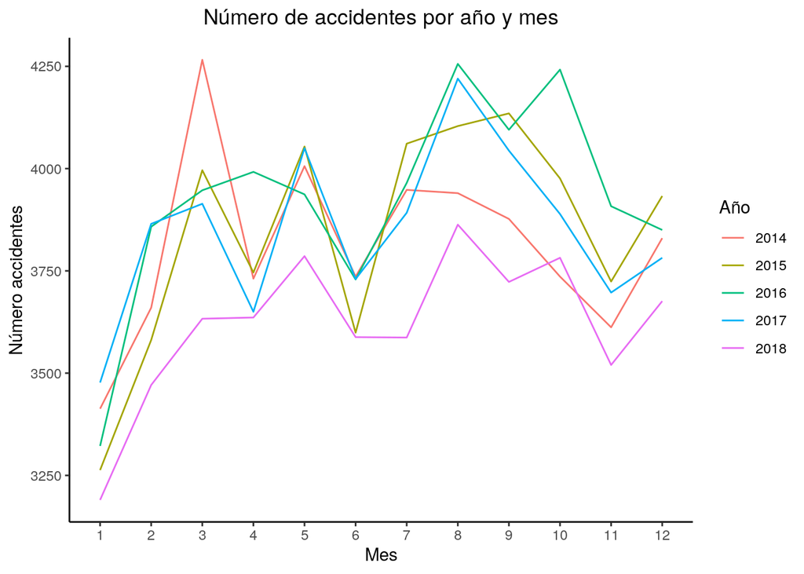

```r
df %>%
  mutate(MES_COD=month(MES)) %>%
  group_by(PERIODO, MES_COD) %>%
  summarise(
    n_accidentes=n(),
    .groups="drop"
  ) %>%
  ggplot() +
  geom_line(aes(x=MES_COD, y=n_accidentes, colour=factor(PERIODO))) +
  scale_x_discrete(name ="Mes", limits=factor(1:12)) +
  labs(colour="Año", y="Número accidentes", title="Número de accidentes por año y mes") +
  theme_classic() +
  theme(plot.title = element_text(hjust = 0.5))
```

Del análisis de tiempo, se pueden ver algunos patrones por meses, pero por año no se ve ninguna diferenciación a nivel general del conjunto de datos, aunque por meses se pueden ver unos leves patrones de cambios. Ahora vamos a analizar por semana del año, día del mes, de la semana y hora del dia.

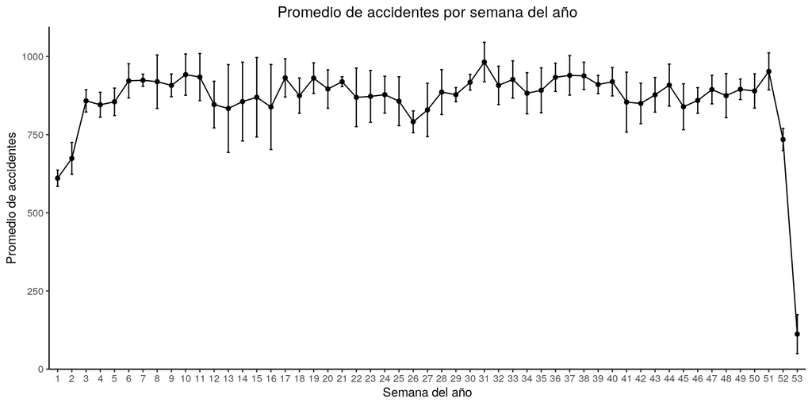

```r
df %>%
  group_by(PERIODO, SEMANA) %>%
  summarise(
    n_accidentes=n(),
    .groups="drop"
  ) %>%
  group_by(SEMANA) %>%
  summarise(
    accidentes=sum(n_accidentes),
    promedio_accidentes=mean(n_accidentes, na.rm = T),
    sd_accidentes=sd(n_accidentes, na.rm = T),
    .groups="drop"
  ) %>%
  ggplot(aes(x=SEMANA, y=promedio_accidentes)) +
  geom_line() +
  geom_point()+
  geom_errorbar(aes(ymin=promedio_accidentes-sd_accidentes, ymax=promedio_accidentes+sd_accidentes), width=.2,
                 position=position_dodge(0.05)) +
  scale_x_discrete(name ="Semana del año", limits=factor(1:53)) +
  theme_classic() + labs(y="Promedio de accidentes") +
  ggtitle("Promedio de accidentes por semana del año") +
  theme(plot.title = element_text(hjust = 0.5))
```

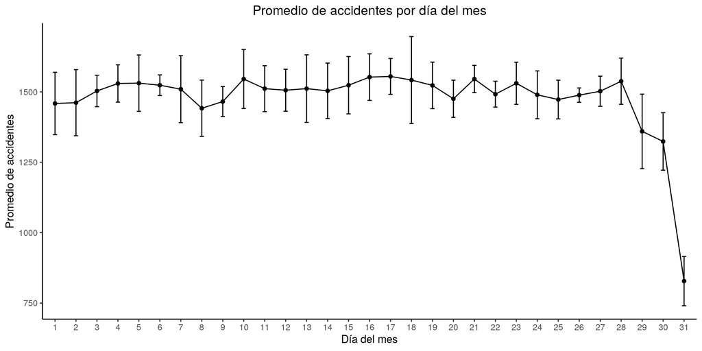

```r
df %>%
  mutate(DIA_MES=day(FECHA)) %>%
  group_by(PERIODO, DIA_MES) %>%
  summarise(
    n_accidentes=n(),
    .groups="drop"
  ) %>%
  group_by(DIA_MES) %>%
  summarise(
    accidentes=sum(n_accidentes),
    promedio_accidentes=mean(n_accidentes, na.rm = T),
    sd_accidentes=sd(n_accidentes, na.rm = T),
    .groups="drop"
  ) %>%
  ggplot(aes(x=DIA_MES, y=promedio_accidentes)) +
  geom_line() +
  geom_point()+
  geom_errorbar(aes(ymin=promedio_accidentes-sd_accidentes, ymax=promedio_accidentes+sd_accidentes), width=.2,
                 position=position_dodge(0.05)) +
  scale_x_discrete(name ="Día del mes", limits=factor(1:31)) +
  theme_classic() + labs(y="Promedio de accidentes") +
  ggtitle("Promedio de accidentes por día del mes") +
  theme(plot.title = element_text(hjust = 0.5))
```

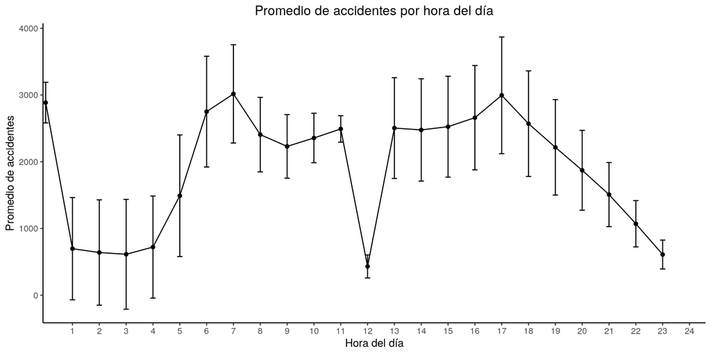

```r
df %>%
  group_by(PERIODO, HORA) %>%
  summarise(
    n_accidentes=n(),
    .groups="drop"
  ) %>%
  group_by(HORA) %>%
  summarise(
    accidentes=sum(n_accidentes),
    promedio_accidentes=mean(n_accidentes, na.rm = T),
    sd_accidentes=sd(n_accidentes, na.rm = T),
    .groups="drop"
  ) %>%
  ggplot(aes(x=HORA, y=promedio_accidentes)) +
  geom_line() +
  geom_point()+
  geom_errorbar(aes(ymin=promedio_accidentes-sd_accidentes, ymax=promedio_accidentes+sd_accidentes), width=.2,
                 position=position_dodge(0.05)) +
  scale_x_discrete(name ="Hora del día", limits=factor(1:24)) +
  theme_classic() + labs(y="Promedio de accidentes") +
  ggtitle("Promedio de accidentes por hora del día") +
  theme(plot.title = element_text(hjust = 0.5))
```

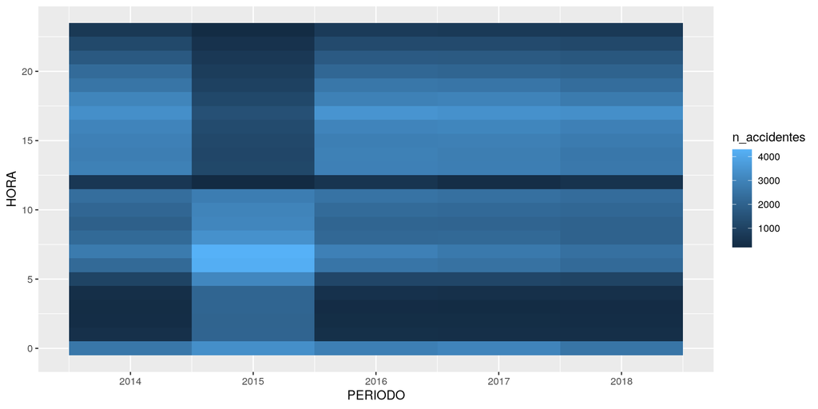

```r
df %>%
  group_by(PERIODO, HORA) %>%
  summarise(
    n_accidentes=n(),
    .groups="drop"
  ) %>%
  ggplot(aes(PERIODO, HORA, fill= n_accidentes)) +
  geom_tile()
```

Se ve un cambio importante en el patrón de accidentes en el año **2015**, el cual por la leyenda de colores, se invierte el comportamiento de los accidentes en la tarde y la mañana, donde se evidenció que a nivel general, se dieron más accidentes en la mañana que en la tarde, veamoslo a nivel de serie.

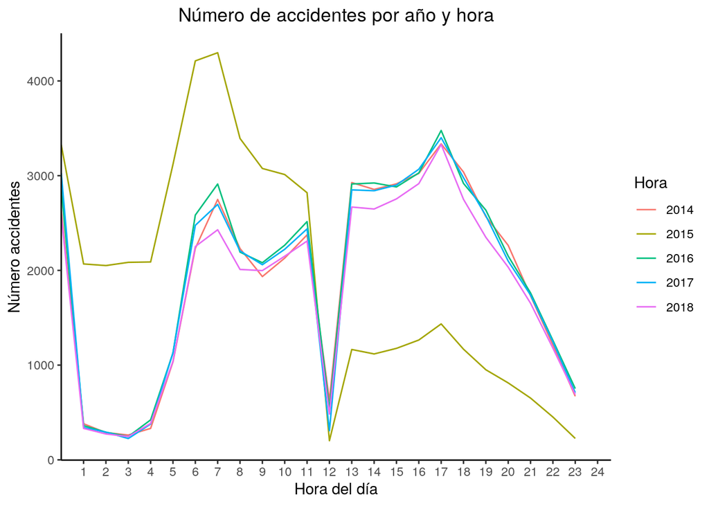

```r
df %>%
  group_by(PERIODO, HORA) %>%
  summarise(
    n_accidentes=n(),
    .groups="drop"
  ) %>%
  ggplot() +
  geom_line(aes(x=HORA, y=n_accidentes, colour=factor(PERIODO))) +
  scale_x_discrete(name ="Hora del día", limits=factor(1:24)) +
  labs(colour="Hora", y="Número accidentes", title="Número de accidentes por año y hora") +
  theme_classic() +
  theme(plot.title = element_text(hjust = 0.5))
```

La difrenciación del 2015 respecto al resto de los años amerita hacer una clusterización específica a ver si se encuentran características diferenciadoras respecto a los demás años, el cual se hará máas adelante.

Vale la pena hacer una diferenciación por año y barrio para evaluar si hay cambios de los niveles de accidentalidad por año, para esto, la próxima tabla presenta el total de accidentes rankeados de forma descendente por año, es decir, el *#1* se refiere al barrio con mayor accidentalidad en un año específico.

```r
df %>%
  filter(BARRIO != "") %>%
  group_by(BARRIO, PERIODO) %>%
  summarise(
    total_accidentes = n(),
    .groups="drop"
  ) %>%
  mutate(PERIODO=paste0("periodo_", PERIODO)) %>%
  pivot_wider(names_from = PERIODO, values_from=total_accidentes) %>%
  mutate(
    periodo_2014=rank(desc(periodo_2014), na.last = T, ties.method = "min"),
    periodo_2015=rank(desc(periodo_2015), na.last = T, ties.method = "min"),
    periodo_2016=rank(desc(periodo_2016), na.last = T, ties.method = "min"),
    periodo_2017=rank(desc(periodo_2017), na.last = T, ties.method = "min"),
    periodo_2018=rank(desc(periodo_2018), na.last = T, ties.method = "min"),
    ) %>%
  arrange(periodo_2018) %>%
  kable() %>% kable_styling(bootstrap_options = c("striped", "hover"), position = "left") %>%
  scroll_box(height = "300px")
```

BARRIO

periodo_2014

periodo_2015

periodo_2016

periodo_2017

periodo_2018

campo amor

3

8

4

4

1

la candelaria

1

1

1

1

2

caribe

2

2

3

2

3

perpetuo socorro

4

5

2

3

4

barrio colon

8

7

8

5

5

santa fe

9

13

9

6

6

los conquistadores

5

6

5

7

7

cabecera san antonio de prado

91

52

57

16

8

san benito

7

4

7

15

9

villa nueva

11

9

13

14

10

carlos e. restrepo

12

11

10

8

11

san diego

13

12

12

11

12

guayaquil

6

3

6

10

13

castilla

18

20

11

12

14

terminal de transporte

10

14

16

9

15

la alpujarra

125

69

110

25

16

villa carlota

23

24

20

21

17

naranjal

14

10

19

19

18

los colores

30

36

27

18

19

belen

19

16

13

20

20

corazon de jesus

15

15

15

24

21

boston

19

18

17

23

22

el progreso

27

33

29

29

23

jesus nazareno

22

22

26

26

24

manila

31

26

28

27

25

prado

17

21

25

28

26

guayabal

21

19

18

13

27

la aguacatala

26

25

22

17

28

el chagualo

16

17

23

30

29

calle nueva

33

32

32

32

30

el poblado

48

38

46

36

31

rosales

36

35

33

34

32

suramericana

28

27

35

31

33

cristo rey

25

28

21

22

34

laureles

35

30

30

35

35

universidad nacional

24

23

24

33

36

las acacias

29

31

31

38

37

estacion villa

44

55

52

42

38

castropol

72

58

72

49

39

cerro nutibara

98

124

111

69

39

moravia

32

34

37

63

41

sevilla

40

44

50

37

42

campo valdes no. 1

39

39

41

53

43

toscana

117

103

105

62

44

barrio colombia

42

63

42

41

45

manrique central no. 1

47

55

39

73

45

facultad de minas u. nacional

48

40

48

51

47

cuarta brigada

54

54

44

39

48

hector abad gomez

77

91

77

63

49

fatima

51

47

54

51

50

san isidro

84

73

53

48

51

tricentenario

73

77

67

55

52

patio bonito

68

79

80

55

53

universidad de antioquia

86

93

99

45

54

el estadio

34

29

34

46

55

lopez de mesa

68

64

67

89

55

la america

43

57

59

44

57

los angeles

52

37

42

47

58

bombona no. 1

36

41

40

65

59

robledo

75

58

61

43

60

san bernardo

71

67

47

59

60

kennedy

65

74

77

75

62

alfonso lopez

46

43

36

70

63

trinidad

50

47

51

67

63

pedregal

70

77

81

77

65

la florida

81

88

87

74

66

los pinos

44

41

49

50

67

las brisas

62

70

58

58

68

bolivariana

59

75

74

71

69

las granjas

38

47

38

72

69

tenche

73

53

45

80

69

el diamante

57

62

63

61

72

alejandro echavarria

82

91

70

77

73

san pedro

60

71

62

79

73

villa flora

89

75

90

91

75

san german

132

114

111

103

76

santa maria de los angeles

80

80

71

40

76

cucaracho

41

47

65

87

78

la gloria

89

71

56

55

78

miranda

52

45

60

59

78

oleoducto

189

163

205

108

81

lorena

67

60

64

85

82

buenos aires

56

46

66

76

83

manrique oriental

64

67

86

83

84

girardot

57

47

55

67

85

tejelo

102

109

77

102

86

florida nueva

86

98

74

81

87

barrio caicedo

61

65

67

85

88

campo valdes no. 2

63

61

76

100

89

calasanz

78

81

84

89

90

el rincon

84

87

73

66

90

parque juan pablo ii

108

123

83

91

92

berlin

78

82

89

81

93

boyaca

138

129

118

118

93

picacho

93

89

82

91

95

el tesoro

119

136

100

107

96

san miguel

66

83

93

88

96

area de expansion pajarito

96

84

98

84

98

la floresta

86

104

88

96

99

el velodromo

105

97

102

97

100

san martin de porres

112

110

122

109

100

alejandria

162

179

131

110

102

san joaquin

102

100

85

127

102

asomadera no. 1

199

204

199

101

104

aures no. 2

138

114

117

119

104

loreto

104

100

100

94

106

enciso

95

98

105

115

107

las palmas

122

112

118

114

107

san javier no.1

82

96

93

94

109

la esperanza

105

95

90

103

110

sucre

94

90

96

115

111

altamira

55

86

103

99

112

la pilarica

147

146

170

143

112

las lomas no.1

120

118

141

135

112

doce de octubre no.1

115

144

132

144

115

los balsos no.2

111

105

95

53

115

belalcazar

134

131

121

112

117

doce de octubre no.2

101

94

116

123

117

santa ines

100

135

125

149

119

cordoba

129

126

159

127

120

villa hermosa

110

118

126

141

120

la castellana

98

66

109

98

122

campo alegre

126

129

127

115

123

palermo

211

197

178

150

123

cabecera urbana san cristobal

113

108

104

133

125

asomadera no. 2

151

148

148

112

126

la salle

122

111

114

127

126

santander

137

144

123

106

126

el salvador

126

117

105

122

129

aures no.1

147

131

148

130

130

miraflores

92

105

96

145

130

brasilia

131

120

159

131

132

villatina

150

139

135

153

132

el raizal

132

152

127

151

134

los naranjos

141

138

170

135

134

la palma

97

102

90

125

136

manrique central no. 2

105

84

113

105

137

francisco antonio zea

108

105

114

110

138

la milagrosa

126

142

132

139

139

los mangos

129

121

137

138

140

santo domingo savio no. 1

116

133

124

155

140

las playas

135

122

105

121

142

el pinal

117

113

132

126

143

nueva villa de la iguana

154

161

155

148

143

santa margarita

238

233

228

184

145

villa del socorro

152

158

139

162

145

gerona

154

139

129

157

147

granada

157

128

135

146

148

popular

113

139

154

157

149

villa guadalupe

162

175

183

165

149

calasanz parte alta

169

182

129

123

151

los alpes

142

156

141

157

152

el nogal-los almendros

162

143

155

141

153

los alcazares

144

146

148

133

153

simon bolivar

179

133

148

157

153

versalles no. 1

122

114

137

139

156

la colina

138

126

118

119

157

playon de los comuneros

185

177

194

175

158

el pomar

178

157

186

172

159

diego echavarria

146

168

165

132

160

palenque

135

152

148

186

160

santa cruz

159

197

194

181

160

moscu no. 1

166

176

167

187

163

aranjuez

173

148

170

154

164

el danubio

158

189

157

135

165

la pinuela

194

152

177

180

165

las mercedes

179

188

157

166

165

florencia

159

172

180

155

168

bombona no. 2

187

167

167

181

169

las lomas no.2

175

209

192

184

169

loma de los bernal

166

168

145

152

169

santa monica

156

158

141

164

169

las violetas

144

171

162

167

173

barrio de jesus

206

204

197

178

174

granizal

159

177

173

178

174

la libertad

174

166

183

191

174

la mota

182

165

148

147

174

bosques de san pablo

179

155

162

162

178

veinte de julio

147

168

173

172

178

bello horizonte

166

158

202

167

180

cementerio universal

213

215

207

230

180

san pablo

169

148

165

169

180

suburbano la loma

214

204

194

221

183

la pradera

152

172

144

161

184

santa teresita

195

191

191

183

184

astorga

171

183

185

193

186

el castillo

208

187

175

191

187

los balsos no.1

172

172

145

187

187

san lucas

219

241

228

193

189

u.d. atanasio girardot

176

186

175

190

189

altavista

162

163

159

175

191

la mansion

199

193

179

170

191

la rosa

199

203

207

221

191

cataluna

187

179

187

205

194

centro administrativo

192

183

181

171

194

las estancias

197

197

192

197

196

moscu no. 2

193

161

187

172

196

san javier no.2

177

202

167

197

196

el pesebre

233

230

204

202

199

ferrini

189

197

187

207

199

la hondonada

229

230

224

201

199

olaya herrera

222

222

230

200

199

santa lucia

206

189

210

175

199

la francia

189

193

205

193

204

andalucia

202

207

199

197

205

altos del poblado

202

193

162

209

206

las esmeraldas

121

125

147

213

207

2. cerro el volador

212

241

217

224

208

la frontera

182

209

212

213

208

jardin botanico

210

212

215

202

210

la isla

208

211

210

233

210

villa niza

216

219

237

218

210

los cerros el vergel

182

201

201

219

213

el compromiso

241

268

253

241

214

hospital san vicente de paul

241

226

221

244

215

inst

224

213

209

231

215

la avanzada

256

259

234

237

215

asomadera no. 3

227

233

224

228

218

el rodeo

222

223

232

207

218

pajarito

274

248

245

233

218

parque norte

143

136

139

209

218

belencito

240

217

226

213

222

bermejal-los alamos

205

191

187

213

222

el diamante no. 2

197

179

181

196

224

fuente clara

274

259

232

244

224

nueva villa de aburra

218

220

221

209

224

el salado

221

207

214

223

227

antonio narino

196

193

202

187

228

barrio cristobal

233

220

218

220

229

la esperanza no. 2

233

244

242

237

229

u.p.b.

260

239

249

202

229

santo domingo savio no. 2

215

217

213

224

232

villa liliam

241

236

243

246

232

facultad veterinaria y zootecnia u.de.a.

185

183

197

229

234

lalinde

231

230

221

209

234

area de expansion altos de calasanz

265

244

254

226

236

juan xxiii la quiebra

217

216

237

213

237

monteclaro

252

254

254

233

237

el progreso no.2

225

228

234

205

239

oriente

254

248

245

254

239

picachito

265

271

267

249

239

suburbano mirador del poblado

274

268

286

254

239

piedras blancas

260

237

260

233

243

suburbano travesias

256

276

245

262

243

aldea pablo vi

252

254

249

265

245

betania

229

254

230

239

246

blanquizal

260

248

243

250

246

carpinelo

248

225

237

254

246

el corazon

241

226

245

239

246

la ladera

256

259

254

253

250

plaza de ferias

225

241

215

231

250

la verde

296

295

300

250

252

suburbano chacaltaya

202

213

218

269

252

area de expansion san antonio de prado

274

259

263

274

254

el triunfo

269

281

275

269

255

la cruz

227

248

254

241

255

nuevos conquistadores

238

233

237

262

255

ocho de marzo

269

265

275

265

258

pedregal alto

287

276

274

269

258

suburbano altavista

248

237

263

247

258

yolombo

308

331

303

302

258

altavista sector central

237

223

226

226

262

pablo vi

246

239

249

247

262

suburbano el llano

280

295

300

269

262

trece de noviembre

272

284

266

254

262

auc1

272

271

279

289

266

campo valdes no.2

246

248

259

274

266

la loma oriental

308

288

291

293

266

las independencias

241

247

263

274

266

miravalle

248

259

234

254

266

versalles no. 2

268

274

279

259

266

bombona no.1

233

248

254

309

272

llanaditas

254

284

268

250

272

area de expansion altavista

263

265

268

285

274

el socorro

248

268

260

267

274

media luna

256

284

279

296

276

villa turbay

269

274

271

293

276

aguas frias

231

244

249

259

278

buga patio bonito

280

254

268

279

278

manrique central no.1

287

295

279

279

278

mirador del doce

280

276

279

267

278

suburbano el tesoro

293

276

296

296

278

suburbano palma patio

287

291

286

279

278

eduardo santos

263

259

275

269

284

juan pablo ii

287

280

275

279

284

maria cano carambolas

265

254

260

259

284

piedras blancas represa

274

288

296

302

284

santa rosa de lima

280

291

303

274

284

la loma de los bernal

285

288

279

274

289

metropolitano

293

265

271

285

289

san jose la cima no. 1

287

271

279

279

289

el picacho

308

281

291

289

292

la oculta

300

305

303

289

292

la sierra

296

305

286

296

292

manrique central no.2

285

284

291

285

292

pedregal bajo

219

228

237

264

292

suburbano palmitas

327

300

291

296

292

aures no.2

300

305

303

323

298

moscu no.2

308

300

296

309

298

san jose la cima no.2

274

291

300

296

298

area de expansion belen rincon

300

300

290

309

301

batallon girardot

315

295

296

296

301

corregimiento de santa elena

296

305

315

309

301

el corazon el morro

293

295

291

302

301

el uvito

318

322

317

327

301

el vergel

319

305

318

302

301

santo domingo savio no.1

300

305

327

302

301

suburbano pedregal alto

287

291

271

309

301

versalles no.1

296

305

303

293

301

barrios de jesus

314

305

313

325

310

el plan

317

321

316

326

310

potrerito

300

305

324

309

310

san antonio

280

281

286

302

310

san jose de la montana

326

327

326

309

310

sin nombre

300

300

328

330

310

villa lilliam

300

300

303

309

310

volcana guayabal

331

330

331

331

310

asomadera no.1

308

317

311

321

318

auc2

300

318

312

322

319

2. cerro el volador

313

319

303

324

320

corregimiento de san antonio de prado

316

320

314

289

321

laureles estadio

320

323

319

279

322

manrique

321

324

320

285

323

moscu no.1

322

305

321

328

324

piedra gorda

323

325

322

309

325

piedras blancas - matasano

324

305

323

329

326

san javier

325

326

325

302

327

suburbano el plan

76

148

218

241

328

suburbano potrerito

328

328

329

309

329

travesias

329

329

330

309

330

versalles no.2

330

305

303

309

331

Lo primero que se observa, es la permanencia de la candelaria y caribe en el top 3 de los barrios con mayor accidentalidad en todos los años de análisis, por lo que puede dar un indicio interesante de que estos barrios pueden pertenecer a los barrios de alta accidentalidad.

```r
df %>%
  filter(PERIODO==2014, DISENO=="") %>%
  mutate(lng=LONGITUD, lat=LATITUD) %>%
  select(lng, lat) %>%
  leaflet() %>%
  addTiles() %>%
  addMarkers(
    clusterOptions = markerClusterOptions(),
  )
```

[interactive chart not shown]

### Calculo de variables para agrupamiento de barrios por año

Para el agrupamiento de los barrios por año, se proponen las siguientes variables:  
- Promedio de accidentes por mes  
- Desviación estandar de accidentes por mes  
- Total de accidentes por tipo de gravedad  
- Total de accidentes por clase de accidente  
- Total de accidentes por diseño de la vía donde ocurrió el accidente

```r
metricas_accidentes_mes <- df %>%
  filter(BARRIO != "") %>%
  group_by(BARRIO, PERIODO, MES) %>%
  summarise(
    total_accidentes = n(),
    .groups="drop"
  ) %>%
  group_by(BARRIO, PERIODO) %>%
  summarise(
    promedio_accidente_mes = mean(total_accidentes, na.rm = T),
    std_accidentes_mes = sd(total_accidentes, na.rm = T),
    .groups="drop"
  )

metricas_variables_dummies <- df %>%
  fastDummies::dummy_cols(select_columns = c("CLASE", "GRAVEDAD", "DISENO")) %>%
  mutate(
    DISENO_TUNEL_PUENTE = `DISENO_paso a nivel` + `DISENO_paso elevado` + `DISENO_paso inferior` + `DISENO_tunel` + `DISENO_puente` + `DISENO_ponton`
  ) %>%
  filter(BARRIO!="") %>%
  rename(
    OTRO_ACCIDENTE=CLASE_otro,
    ATROPELLOS=CLASE_atropello,
    CAIDA_OCUPANTE=`CLASE_caida ocupante`,
    CHOQUE=CLASE_choque,
    INCENDIO=CLASE_incendio,
    VOLCAMIENTOS=CLASE_volcamiento,
    HERIDO=GRAVEDAD_herido,
    MUERTO=GRAVEDAD_muerto,
    SOLO_DANOS=`GRAVEDAD_solo danos`,
    SIN_DISENO=DISENO_,
    CICLO_RUTA=`DISENO_ciclo ruta`,
    GLORIETA=DISENO_glorieta,
    INTERSECCION=DISENO_interseccion,
    LOTE_PREDIO=`DISENO_lote o predio`,
    TRAMO_VIDA=`DISENO_tramo de via`,
    VIA_PEATOLNAL=`DISENO_via peatonal`
  ) %>%
  group_by(BARRIO, PERIODO, MES) %>%
  summarise(
    TOTAL_OTRO_ACCIDENTE = sum(OTRO_ACCIDENTE),
    TOTAL_ATROPELLOS=sum(ATROPELLOS),
    TOTAL_CAIDA_OCUPANTE=sum(CAIDA_OCUPANTE),
    TOTAL_CHOQUE=sum(CHOQUE),
    TOTAL_INCENDIO=sum(INCENDIO),
    TOTAL_VOLCAMIENTOS=sum(VOLCAMIENTOS),
    TOTAL_HERIDO=sum(HERIDO),
    TOTAL_MUERTO=sum(MUERTO),
    TOTAL_SOLO_DANOS=sum(SOLO_DANOS),
    TOTAL_SIN_DISENO=sum(SIN_DISENO),
    TOTAL_CICLO_RUTA=sum(CICLO_RUTA),
    TOTAL_GLORIETA=sum(GLORIETA),
    TOTAL_INTERSECCION=sum(INTERSECCION),
    TOTAL_LOTE_PREDIO=sum(LOTE_PREDIO),
    TOTAL_TRAMO_VIDA=sum(TRAMO_VIDA),
    TOTAL_VIA_PEATOLNAL=sum(VIA_PEATOLNAL),
    TOTAL_DISENO_TUNEL_PUENTE = sum(DISENO_TUNEL_PUENTE),
    .groups="drop"
  )  %>%
  group_by(BARRIO, PERIODO) %>%
  summarise(
    AVG_OTRO_ACCIDENTE = sum(TOTAL_OTRO_ACCIDENTE),
    AVG_ATROPELLOS=sum(TOTAL_ATROPELLOS),
    AVG_CAIDA_OCUPANTE=sum(TOTAL_CAIDA_OCUPANTE),
    AVG_CHOQUE=sum(TOTAL_CHOQUE),
    AVG_INCENDIO=sum(TOTAL_INCENDIO),
    AVG_VOLCAMIENTOS=sum(TOTAL_VOLCAMIENTOS),
    AVG_HERIDO=sum(TOTAL_HERIDO),
    AVG_MUERTO=sum(TOTAL_MUERTO),
    AVG_SOLO_DANOS=sum(TOTAL_SOLO_DANOS),
    AVG_SIN_DISENO=sum(TOTAL_SIN_DISENO),
    AVG_CICLO_RUTA=sum(TOTAL_CICLO_RUTA),
    AVG_GLORIETA=sum(TOTAL_GLORIETA),
    AVG_INTERSECCION=sum(TOTAL_INTERSECCION),
    AVG_LOTE_PREDIO=sum(TOTAL_LOTE_PREDIO),
    AVG_TRAMO_VIDA=sum(TOTAL_TRAMO_VIDA),
    AVG_VIA_PEATOLNAL=sum(TOTAL_VIA_PEATOLNAL),
    AVG_DISENO_TUNEL_PUENTE = sum(TOTAL_DISENO_TUNEL_PUENTE),
    .groups="drop"
  )

cluster_df <- merge(metricas_accidentes_mes, metricas_variables_dummies, by = c("BARRIO", "PERIODO"))
cluster_df_dim <- dim(cluster_df)
```

De la construcción de variables del conjunto de datos inicial, resultamos con un conjunto de datos de 1575 observaciones por 21 variables, sin embargo, al ser de nuestro interes hacer un clustering por año, el resultado son 5 conjuntos de datos con aproximadamente 315 observaciones por conjinto de datos. A continuación se puede visualizar la tabla resultante.

```r
cluster_df %>%
  kable() %>%
  kable_styling(bootstrap_options = c("striped", "hover"), position = "left") %>%
  scroll_box(height = "300px")
```

BARRIO

PERIODO

promedio_accidente_mes

std_accidentes_mes

AVG_OTRO_ACCIDENTE

AVG_ATROPELLOS

AVG_CAIDA_OCUPANTE

AVG_CHOQUE

AVG_INCENDIO

AVG_VOLCAMIENTOS

AVG_HERIDO

AVG_MUERTO

AVG_SOLO_DANOS

AVG_SIN_DISENO

AVG_CICLO_RUTA

AVG_GLORIETA

AVG_INTERSECCION

AVG_LOTE_PREDIO

AVG_TRAMO_VIDA

AVG_VIA_PEATOLNAL

AVG_DISENO_TUNEL_PUENTE

aguas frias

2014

2.272727

1.1037127

3

5

6

10

0

1

22

0

3

0

0

0

1

1

23

0

0

aguas frias

2015

1.900000

0.7378648

2

3

1

13

0

0

10

0

9

0

0

1

2

0

16

0

0

aguas frias

2016

2.222222

1.0929064

3

3

2

10

0

2

14

0

6

0

0

0

0

1

19

0

0

aguas frias

2017

1.555556

0.8819171

5

3

2

3

0

1

12

0

2

0

0

0

0

9

5

0

0

aguas frias

2018

1.750000

0.5000000

1

2

1

3

0

0

5

0

2

0

0

0

0

2

5

0

0

aldea pablo vi

2014

1.700000

0.6749486

4

4

2

7

0

0

14

0

3

0

0

0

2

0

15

0

0

aldea pablo vi

2015

1.363636

0.6741999

0

7

0

7

0

1

12

0

3

0

0

0

0

1

14

0

0

aldea pablo vi

2016

1.818182

0.8738629

2

9

5

4

0

0

17

0

3

0

0

0

0

1

19

0

0

aldea pablo vi

2017

1.571429

0.7867958

1

4

1

5

0

0

9

1

1

1

0

0

0

3

7

0

0

aldea pablo vi

2018

2.000000

0.8164966

1

3

4

12

0

0

12

1

7

0

0

0

0

4

16

0

0

alejandria

2014

6.500000

3.3439226

3

2

2

70

0

1

18

0

60

0

0

0

10

5

63

0

0

alejandria

2015

5.333333

2.6400184

1

1

4

58

0

0

18

0

46

0

0

1

6

8

49

0

0

alejandria

2016

8.750000

2.7010099

6

1

3

93

0

2

35

0

70

0

0

0

20

6

79

0

0

alejandria

2017

10.250000

2.0504988

7

4

3

108

0

1

24

1

98

1

0

1

21

27

73

0

0

alejandria

2018

10.750000

2.5271256

8

6

6

105

0

4

37

0

92

0

1

1

20

21

85

0

1

alejandro echavarria

2014

13.500000

2.0225996

28

29

18

76

0

11

126

1

35

1

0

1

22

5

133

0

0

alejandro echavarria

2015

12.166667

3.9733964

24

17

12

85

0

8

103

0

43

0

0

3

17

9

117

0

0

alejandro echavarria

2016

15.583333

3.3698755

31

20

22

101

0

13

145

1

41

1

1

1

28

11

145

0

0

alejandro echavarria

2017

15.000000

3.2473766

22

15

13

121

0

9

117

0

63

0

1

2

46

23

108

0

0

alejandro echavarria

2018

14.750000

4.7505980

21

17

25

104

0

10

114

0

63

0

1

2

38

35

100

0

1

alfonso lopez

2014

19.500000

6.2885177

42

20

39

129

0

4

152

3

79

3

1

0

19

9

202

0

0

alfonso lopez

2015

20.416667

5.3675512

35

33

30

138

0

9

160

0

85

0

2

0

27

3

213

0

0

alfonso lopez

2016

24.083333

3.9876704

50

37

42

145

0

15

204

1

84

1

1

0

39

7

241

0

0

alfonso lopez

2017

16.250000

4.4746762

34

20

25

103

0

13

132

1

62

1

4

0

21

27

142

0

0

alfonso lopez

2018

15.500000

4.9267360

21

22

42

93

0

8

124

1

61

1

1

0

32

58

94

0

0

altamira

2014

18.000000

3.3303017

34

19

39

121

0

3

145

1

70

1

2

0

25

13

175

0

0

altamira

2015

13.500000

4.2103768

22

12

25

101

0

2

100

0

62

0

1

0

16

12

133

0

0

altamira

2016

11.416667

3.7769236

18

7

22

87

0

3

88

0

49

0

0

2

14

8

113

0

0

altamira

2017

11.833333

4.8210397

11

4

35

86

0

6

97

1

44

1

4

3

18

26

90

0

0

altamira

2018

9.916667

2.5746433

15

8

23

71

0

2

74

0

45

0

0

2

21

31

65

0

0

altavista

2014

6.500000

2.3931721

10

15

7

43

0

3

47

0

31

0

2

0

13

6

57

0

0

altavista

2015

6.416667

1.8809250

5

15

2

54

0

1

39

0

38

0

0

0

11

6

60

0

0

altavista

2016

6.833333

2.0375267

10

15

9

46

0

2

51

0

31

0

0

0

12

1

69

0

0

altavista

2017

5.250000

2.2207697

12

7

7

33

0

4

44

0

19

0

0

0

13

11

39

0

0

altavista

2018

4.416667

2.3532698

7

10

4

30

0

2

33

2

18

2

0

0

8

7

36

0

0

altavista sector central

2014

1.916667

0.9962049

4

5

6

8

0

0

18

0

5

0

1

0

0

3

19

0

0

altavista sector central

2015

2.727273

1.6180797

4

8

5

12

0

1

22

3

5

3

0

0

2

3

22

0

0

altavista sector central

2016

2.727273

1.4206273

9

1

6

10

0

4

23

1

6

1

0

0

4

3

22

0

0

altavista sector central

2017

2.500000

0.7977240

10

4

4

10

0

2

24

1

5

1

1

0

0

5

23

0

0

altavista sector central

2018

2.000000

1.5491933

1

4

0

7

0

0

9

0

3

0

0

0

0

1

11

0

0

altos del poblado

2014

4.083333

2.0207259

1

1

3

44

0

0

19

0

30

0

0

1

5

1

42

0

0

altos del poblado

2015

4.500000

1.8829377

3

2

4

43

0

2

23

0

31

0

0

0

6

5

43

0

0

altos del poblado

2016

6.666667

2.3094011

5

8

8

52

0

7

48

0

32

0

0

0

14

6

60

0

0

altos del poblado

2017

3.727273

1.6180797

6

1

2

31

0

1

19

0

22

0

1

0

4

7

27

0

2

altos del poblado

2018

3.818182

1.9908883

8

3

2

29

0

0

17

0

25

0

0

0

2

10

30

0

0

andalucia

2014

4.083333

2.1933094

1

14

6

26

0

2

31

1

17

1

0

0

5

0

43

0

0

andalucia

2015

3.916667

1.4433757

8

12

5

21

0

1

32

1

14

1

1

0

1

1

43

0

0

andalucia

2016

4.727273

1.9021519

10

13

3

24

0

2

31

1

20

1

0

0

2

4

45

0

0

andalucia

2017

4.083333

1.9286516

5

14

5

20

0

5

36

0

13

0

1

0

4

6

38

0

0

andalucia

2018

3.583333

1.7298625

6

5

6

24

0

2

29

0

14

0

0

0

10

12

21

0

0

antonio narino

2014

4.416667

1.7298625

10

9

10

22

0

2

45

0

8

0

1

0

4

3

45

0

0

antonio narino

2015

4.909091

1.7002674

9

8

16

17

0

4

43

0

11

0

0

0

4

0

50

0

0

antonio narino

2016

4.545454

2.0670576

8

9

7

22

0

4

39

0

11

0

0

0

5

3

42

0

0

antonio narino

2017

4.500000

2.5045413

6

9

9

25

0

5

42

0

12

0

0

0

7

14

33

0

0

antonio narino

2018

2.636364

1.2060454

5

5

4

13

0

2

21

0

8

0

0

0

6

13

10

0

0

aranjuez

2014

6.000000

2.5584086

9

11

10

41

0

1

52

0

20

0

0

1

14

1

56

0

0

aranjuez

2015

7.166667

2.9180733

12

17

6

44

0

7

65

1

20

1

0

0

19

0

66

0

0

aranjuez

2016

6.083333

2.3143164

7

11

13

39

0

3

49

1

23

1

0

1

10

3

58

0

0

aranjuez

2017

6.916667

3.9186810

10

12

5

50

0

6

51

8

24

8

0

0

15

15

45

0

0

aranjuez

2018

5.583333

2.5030285

8

8

16

35

0

0

46

0

21

0

0

0

10

14

43

0

0

area de expansion altavista

2014

1.444444

0.5270463

0

2

5

5

0

1

10

0

3

0

0

0

1

0

12

0

0

area de expansion altavista

2015

1.857143

1.2149858

1

4

1

6

0

1

12

0

1

0

0

0

2

1

10

0

0

area de expansion altavista

2016

2.400000

1.3416408

3

4

4

1

0

0

12

0

0

0

0

0

0

0

12

0

0

area de expansion altavista

2017

1.200000

0.4472136

1

0

0

5

0

0

3

0

3

0

0

0

0

1

5

0

0

area de expansion altavista

2018

1.285714

0.4879500

2

3

0

4

0

0

7

0

2

0

0

0

1

1

7

0

0

area de expansion altos de calasanz

2014

2.000000

0.8944272

0

3

1

8

0

0

6

0

6

0

0

0

0

1

11

0

0

area de expansion altos de calasanz

2015

1.900000

1.4491377

1

1

1

15

0

1

10

0

9

0

0

0

0

1

18

0

0

area de expansion altos de calasanz

2016

1.800000

1.2292726

3

0

1

14

0

0

8

1

9

1

0

0

1

3

13

0

0

area de expansion altos de calasanz

2017

2.727273

1.3483997

4

4

4

17

0

1

17

0

13

0

0

0

1

9

20

0

0

area de expansion altos de calasanz

2018

2.181818

1.3280197

1

1

1

20

0

1

10

0

14

0

0

0

1

4

19

0

0

area de expansion belen rincon

2014

1.000000

0.0000000

1

1

0

0

0

0

2

0

0

0

0

0

1

0

1

0

0

area de expansion belen rincon

2015

1.000000

0.0000000

0

0

0

2

0

0

2

0

0

0

0

0

0

0

2

0

0

area de expansion belen rincon

2016

1.250000

0.5000000

1

0

0

4

0

0

3

0

2

0

0

0

0

0

5

0

0

area de expansion belen rincon

2017

1.000000

NA

0

0

0

1

0

0

0

0

1

0

0

0

0

1

0

0

0

area de expansion belen rincon

2018

1.000000

0.0000000

0

0

0

2

0

0

0

0

2

0

0

0

0

0

2

0

0

area de expansion pajarito

2014

11.750000

4.2879323

22

24

23

68

0

4

108

2

31

2

0

0

7

4

128

0

0

area de expansion pajarito

2015

13.666667

3.0846639

24

19

34

78

0

9

129

0

35

0

0

0

17

8

139

0

0

area de expansion pajarito

2016

12.166667

4.3866188

36

19

23

61

1

6

113

1

32

1

1

0

11

14

118

0

1

area de expansion pajarito

2017

13.833333

5.5240521

31

16

31

78

0

10

117

3

46

3

0

0

21

35

105

0

2

area de expansion pajarito

2018

11.416667

3.6045006

17

14

23

72

0

11

102

3

32

2

0

0

15

44

75

0

1

area de expansion san antonio de prado

2014

1.000000

0.0000000

0

3

0

5

0

0

5

0

3

0

0

0

0

0

8

0

0

area de expansion san antonio de prado

2015

1.555556

0.7264832

1

1

3

8

0

1

11

0

3

0

0

0

1

1

12

0

0

area de expansion san antonio de prado

2016

1.500000

0.7071068

3

1

0

10

0

1

10

1

4

1

0

0

0

1

13

0

0

area de expansion san antonio de prado

2017

2.000000

1.4142136

1

0

1

6

0

0

4

1

3

1

0

0

1

0

6

0

0

area de expansion san antonio de prado

2018

2.142857

0.6900656

2

2

2

8

0

1

12

0

3

0

0

1

1

6

6

0

1

asomadera no. 1

2014

4.166667

1.9462474

5

3

4

38

0

0

20

0

30

0

0

0

8

1

41

0

0

asomadera no. 1

2015

4.000000

1.9069252

5

4

4

34

0

1

26

0

22

0

0

0

2

0

45

0

1

asomadera no. 1

2016

4.727273

2.4120908

5

0

5

38

0

4

27

0

25

0

0

0

4

1

47

0

0

asomadera no. 1

2017

11.500000

6.0527980

7

3

5

110

0

13

52

0

86

0

0

0

12

13

109

0

4

asomadera no. 1

2018

10.583333

3.6296339

9

6

6

103

0

3

42

1

84

1

0

0

12

16

95

0

3

asomadera no. 2

2014

7.333333

2.6400184

12

1

3

67

0

5

35

1

52

1

0

0

6

4

76

0

1

asomadera no. 2

2015

7.166667

2.5524795

8

3

3

70

0

2

31

0

55

0

1

0

4

9

72

0

0

asomadera no. 2

2016

7.416667

2.7784343

9

1

8

68

0

3

39

0

50

0

0

0

4

10

75

0

0

asomadera no. 2

2017

10.166667

3.7859389

9

3

3

99

0

8

39

0

83

0

1

0

18

11

92

0

0

asomadera no. 2

2018

8.666667

3.0846639

8

0

7

87

0

2

37

0

67

0

0

1

10

10

83

0

0

asomadera no. 3

2014

2.454546

1.2933396

3

0

3

20

0

1

11

0

16

0

1

0

3

3

20

0

0

asomadera no. 3

2015

2.500000

1.5092309

1

1

4

17

0

2

13

1

11

1

0

0

5

0

19

0

0

asomadera no. 3

2016

2.583333

1.1645002

4

0

2

23

0

2

14

0

17

0

0

0

3

0

28

0

0

asomadera no. 3

2017

2.900000

1.1005049

2

1

1

22

0

3

11

0

18

0

0

1

3

3

22

0

0

asomadera no. 3

2018

2.750000

1.4847712

4

0

4

23

0

2

16

0

17

0

0

0

4

4

25

0

0

asomadera no.1

2014

1.000000

NA

0

0

0

1

0

0

0

1

0

1

0

0

0

0

0

0

0

astorga

2014

6.166667

3.0401356

2

4

3

65

0

0

29

0

45

0

1

0

20

0

53

0

0

astorga

2015

5.083333

2.4293034

1

2

0

58

0

0

16

0

45

0

0

0

24

3

34

0

0

astorga

2016

4.916667

2.1933094

3

3

1

52

0

0

20

0

39

0

0

0

12

0

47

0

0

astorga

2017

4.250000

2.4167973

4

2

1

42

0

2

18

0

33

0

0

0

27

2

22

0

0

astorga

2018

4.666667

2.1881222

4

0

1

49

0

2

21

0

35

0

0

0

31

4

21

0

0

auc1

2014

1.500000

0.5477226

1

4

0

4

0

0

7

1

1

1

0

0

0

0

8

0

0

auc1

2015

1.222222

0.4409586

1

2

3

5

0

0

7

1

3

1

0

0

0

0

10

0

0

auc1

2016

1.142857

0.3779645

1

1

2

4

0

0

6

0

2

0

0

0

0

0

8

0

0

auc1

2017

1.000000

0.0000000

1

0

1

3

0

0

5

0

0

0

0

0

0

1

4

0

0

auc1

2018

1.833333

1.6020820

2

2

2

5

0

0

8

0

3

0

0

0

1

5

5

0

0

auc2

2014

1.000000

0.0000000

1

0

0

1

0

0

1

0

1

0

0

0

0

0

2

0

0

aures no. 2

2014

8.083333

2.4664414

21

14

29

31

0

2

83

0

14

0

0

0

8

2

87

0

0

aures no. 2

2015

9.583333

3.6545945

33

12

30

33

0

7

98

0

17

0

0

0

10

10

94

0

1

aures no. 2

2016

10.000000

3.5419563

24

12

32

46

0

6

91

1

28

1

0

0

14

10

95

0

0

aures no. 2

2017

9.750000

5.2070756

18

22

30

39

0

8

95

0

22

0

1

0

20

27

68

0

1

aures no. 2

2018

10.583333

4.3995523

25

14

28

48

0

12

98

1

28

1

2

0

20

45

55

0

4

aures no.1

2014

7.500000

2.8762349

26

15

26

22

0

1

77

0

13

0

0

0

4

5

81

0

0

aures no.1

2015

8.416667

3.1754265

23

17

24

32

0

5

78

1

22

1

0

0

11

11

78

0

0

aures no.1

2016

7.416667

2.3532698

25

12

18

31

0

3

74

1

14

1

0

0

9

4

75

0

0

aures no.1

2017

8.750000

2.5628464

17

17

19

41

0

11

79

1

25

1

0

0

22

19

63

0

0

aures no.1

2018

8.416667

2.5030285

17

14

23

44

0

3

78

0

23

0

0

0

12

33

56

0

0

aures no.2

2014

1.000000

0.0000000

1

0

1

0

0

0

2

0

0

0

1

0

0

0

1

0

0

aures no.2

2015

1.000000

NA

1

0

0

0

0

0

1

0

0

0

0

0

0

0

1

0

0

aures no.2

2016

1.000000

NA

0

0

0

1

0

0

0

0

1

0

0

0

0

0

1

0

0

aures no.2

2018

1.000000

0.0000000

1

0

0

2

0

0

2

0

1

0

0

0

0

1

2

0

0

2. cerro el volador

2014

3.500000

1.8829377

7

6

4

25

0

0

22

0

20

0

0

0

7

1

34

0

0

2. cerro el volador

2015

2.625000

0.9161254

3

4

0

14

0

0

11

0

10

0

0

0

1

0

20

0

0

2. cerro el volador

2016

3.090909

1.2210279

7

7

6

14

0

0

25

0

9

0

0

0

2

1

31

0

0

2. cerro el volador

2017

2.909091

1.3003496

1

6

3

21

0

1

20

0

12

0

0

0

4

3

25

0

0

2. cerro el volador

2018

3.545454

1.1281521

4

4

3

27

0

1

21

1

17

1

0

0

4

6

28

0

0

2. cerro el volador

2016

1.000000

NA

0

0

0

1

0

0

0

1

0

1

0

0

0

0

0

0

0

barrio caicedo

2014

16.833333

3.7859389

31

25

25

110

0

11

126

2

74

2

0

1

47

7

145

0

0

barrio caicedo

2015

16.333333

5.0332230

19

31

30

103

0

13

135

2

59

2

1

5

39

6

143

0

0

barrio caicedo

2016

15.833333

4.2175679

36

27

18

100

0

9

125

1

64

1

1

5

31

8

144

0

0

barrio caicedo

2017

13.750000

2.8001623

24

15

18

98

0

10

93

1

71

1

2

6

39

24

91

0

2

barrio caicedo

2018

12.916667

3.2879486

14

18

17

97

0

9

94

1

60

1

2

6

43

26

75

0

2

barrio colombia

2014

20.166667

5.0781767

21

15

18

184

0

4

110

3

129

3

2

1

18

6

211

1

0

barrio colombia

2015

16.666667

3.2003788

20

12

13

151

0

4

97

0

103

0

0

3

13

6

178

0

0

barrio colombia

2016

20.750000

4.4338573

20

17

20

185

0

7

117

0

132

0

0

2

35

8

204

0

0

barrio colombia

2017

22.500000

6.8290822

17

9

9

231

0

4

100

1

169

1

0

7

42

17

203

0

0

barrio colombia

2018

19.083333

5.2476546

13

6

10

195

0

5

89

3

137

3

0

2

54

20

149

0

1

barrio colon

2014

57.083333

6.3023565

43

62

38

534

0

8

281

2

402

2

1

13

93

12

550

0

14

barrio colon

2015

62.250000

10.3671246

51

75

35

570

0

16

318

3

426

3

3

13

118

8

592

0

10

barrio colon

2016

58.583333

6.9603857

49

61

37

544

0

12

268

3

432

3

3

17

127

12

526

0

15

barrio colon

2017

62.333333

11.0891703

47

61

37

590

0

13

281

1

466

1

1

28

164

36

502

0

16

barrio colon

2018

62.250000

8.5930733

41

60

24

613

0

9

254

7

486

5

2

14

178

50

478

0

20

barrio cristobal

2014

2.181818

0.8738629

2

2

2

18

0

0

13

0

11

0

0

0

4

0

20

0

0

barrio cristobal

2015

3.400000

2.1705094

3

2

2

27

0

0

17

0

17

0

0

0

6

1

27

0

0

barrio cristobal

2016

3.300000

1.8287822

2

6

3

21

0

1

22

1

10

1

0

0

12

0

20

0

0

barrio cristobal

2017

2.916667

1.4433757

3

2

2

28

0

0

22

0

13

0

0

0

15

4

16

0

0

barrio cristobal

2018

2.333333

1.6143298

5

0

3

20

0

0

16

0

12

0

1

0

10

4

13

0

0

barrio de jesus

2014

4.181818

1.3280197

9

8

8

21

0

0

33

1

12

1

0

0

1

2

42

0

0

barrio de jesus

2015

4.000000

1.9069252

4

9

9

24

0

2

29

1

18

1

0

0

5

0

42

0

0

barrio de jesus

2016

4.416667

2.7122059

6

9

6

27

0

5

36

0

17

0

0

0

5

1

47

0

0

barrio de jesus

2017

5.166667

2.0375267

7

12

8

31

0

4

43

1

18

1

2

0

2

13

44

0

0

barrio de jesus

2018

5.166667

1.6966991

14

5

5

38

0

0

38

1

23

1

0

0

5

9

45

0

2

barrios de jesus

2015

1.000000

NA

0

0

0

1

0

0

0

0

1

0

0

0

0

0

1

0

0

barrios de jesus

2018

1.000000

NA

0

1

0

0

0

0

1

0

0

0

0

0

0

0

1

0

0

batallon girardot

2015

1.500000

0.7071068

0

2

0

1

0

0

3

0

0

0

0

0

0

1

2

0

0

batallon girardot

2016

1.500000

0.7071068

0

2

0

1

0

0

2

0

1

0

0

0

1

0

2

0

0

batallon girardot

2017

1.000000

0.0000000

0

1

0

2

0

0

2

0

1

0

1

0

0

1

1

0

0

batallon girardot

2018

1.000000

0.0000000

0

1

1

0

0

0

2

0

0

0

0

0

0

1

1

0

0

belalcazar

2014

8.333333

2.9644357

20

4

11

63

0

2

62

3

35

3

0

0

11

1

84

0

1

belalcazar

2015

8.416667

3.6545945

14

7

3

76

0

1

56

0

45

0

1

0

4

2

94

0

0

belalcazar

2016

9.750000

3.0488448

13

9

10

80

0

5

66

1

50

1

0

0

6

5

105

0

0

belalcazar

2017

10.166667

2.8230652

9

8

8

94

0

3

59

0

63

0

0

0

6

8

108

0

0

belalcazar

2018

9.666667

3.2566947

17

5

6

85

0

3

63

0

53

0

2

0

5

12

97

0

0

belen

2014

37.333333

8.6058472

37

47

39

315

0

10

203

3

242

3

3

33

55

22

332

0

0

belen

2015

40.583333

9.0197595

36

45

28

362

0

16

214

0

273

0

0

39

62

16

370

0

0

belen

2016

46.000000

6.8357350

44

40

31

415

0

22

254

2

296

2

2

50

76

36

386

0

0

belen

2017

42.166667

6.2643774

46

33

25

392

0

10

213

9

284

9

3

78

85

69

258

0

4

belen

2018

37.916667

5.9154395

25

23

24

377

0

6

163

0

292

0

1

77

84

47

246

0

0

belencito

2014

2.333333

1.7320508

4

5

2

10

0

0

18

0

3

0

0

0

2

0

19

0

0

belencito

2015

3.272727

1.7372915

5

6

4

20

0

1

26

0

10

0

0

0

2

0

34

0

0

belencito

2016

2.500000

1.7837652

5

1

4

19

0

1

23

0

7

0

0

0

1

0

29

0

0

belencito

2017

3.333333

1.6696942

11

6

1

22

0

0

27

1

12

1

0

0

6

7

26

0

0

belencito

2018

2.666667

1.6696942

5

5

4

17

0

1

20

1

11

0

0

0

3

7

22

0

0

bello horizonte

2014

6.333333

2.2292817

14

8

6

48

0

0

47

0

29

0

0

0

17

4

55

0

0

bello horizonte

2015

6.583333

2.4664414

8

15

10

42

0

4

59

0

20

0

0

0

15

1

63

0

0

bello horizonte

2016

4.166667

1.7494588

4

9

5

29

0

3

36

1

13

1

0

0

10

3

36

0

0

bello horizonte

2017

5.833333

1.9924098

7

8

8

44

0

3

45

0

25

0

0

0

25

5

40

0

0

bello horizonte

2018

5.000000

2.2156468

4

11

12

30

0

3

40

0

20

0

0

0

13

13

34

0

0

berlin

2014

13.916667

3.8954130

17

46

24

77

0

3

115

3

49

3

2

0

25

4

133

0

0

berlin

2015

14.083333

4.1000739

18

35

21

88

0

7

131

1

37

1

0

0

37

4

127

0

0

berlin

2016

12.833333

3.9504507

22

30

17

80

0

5

102

0

52

0

0

0

29

9

116

0

0

berlin

2017

14.333333

4.0526834

24

31

17

94

0

6

109

1

62

1

0

0

51

15

105

0

0

berlin

2018

12.333333

3.3933982

19

20

17

88

0

4

86

0

62

0

1

0

42

23

82

0

0

bermejal-los alamos

2014

4.000000

2.6628761

3

14

3

25

0

3

28

0

20

0

0

0

3

1

44

0

0

bermejal-los alamos

2015

5.000000

2.4899799

7

14

8

25

0

1

45

1

9

1

0

0

2

2

50

0

0

bermejal-los alamos

2016

4.750000

1.9128750

8

16

4

28

0

1

38

1

18

1

0

0

2

1

53

0

0

bermejal-los alamos

2017

3.333333

2.0150946

5

10

3

20

0

2

26

0

14

0

0

0

5

7

27

0

1

bermejal-los alamos

2018

2.666667

1.2309149

6

9

4

12

0

1

24

0

8

0

0

0

5

10

17

0

0

betania

2014

2.363636

1.1200649

8

8

7

2

0

1

25

0

1

0

0

1

0

1

24

0

0

betania

2015

1.500000

0.8498366

2

5

2

6

0

0

13

0

2

0

0

0

1

1

13

0

0

betania

2016

2.454546

0.9341987

2

2

7

14

0

2

16

1

10

1

0

0

3

3

20

0

0

betania

2017

2.555556

1.6666667

5

3

6

7

0

2

18

0

5

0

0

0

3

8

12

0

0

betania

2018

1.727273

1.1037127

1

2

4

11

0

1

9

1

9

1

0

0

3

9

5

0

1

blanquizal

2014

1.555556

0.7264832

5

2

2

4

0

1

10

0

4

0

0

0

0

0

14

0

0

blanquizal

2015

2.666667

1.8618987

2

4

4

5

0

1

13

1

2

1

0

0

1

0

14

0

0

blanquizal

2016

2.200000

1.3984118

4

3

4

10

0

1

18

0

4

0

1

0

2

0

18

0

1

blanquizal

2017

2.428571

0.9759001

2

3

1

9

0

2

10

0

7

0

0

0

1

3

13

0

0

blanquizal

2018

1.900000

0.8755950

2

4

0

11

0

2

11

0

8

0

0

0

1

2

15

0

1

bolivariana

2014

17.250000

6.0771554

15

9

12

165

0

6

106

0

101

0

1

1

55

7

142

1

0

bolivariana

2015

14.916667

4.0104031

12

12

10

140

0

5

95

1

83

1

0

1

43

4

130

0

0

bolivariana

2016

14.750000

5.0654803

14

7

8

145

0

3

88

0

89

0

0

2

43

8

124

0

0

bolivariana

2017

16.083333

2.9682665

13

10

11

157

0

2

87

0

106

0

1

1

61

22

108

0

0

bolivariana

2018

14.916667

4.5218326

12

11

13

138

0

5

81

0

98

0

1

2

58

28

90

0

0

bombona no. 1

2014

22.333333

7.3772788

16

18

12

218

0

4

116

2

150

2

0

0

75

0

191

0

0

bombona no. 1

2015

20.666667

3.9157800

17

22

8

195

0

6

118

1

129

1

0

0

70

4

172

0

1

bombona no. 1

2016

21.000000

3.4902461

31

13

17

181

0

10

126

1

125

1

2

0

77

1

171

0

0

bombona no. 1

2017

16.833333

3.1285586

15

8

12

164

0

3

77

1

124

1

0

0

69

9

123

0

0

bombona no. 1

2018

16.166667

4.2175679

9

18

8

154

0

5

84

2

108

1

1

0

68

23

101

0

0

bombona no. 2

2014

5.083333

1.0836247

6

5

6

40

0

4

37

0

24

0

0

0

5

1

55

0

0

bombona no. 2

2015

6.083333

3.1466673

13

11

7

37

0

5

46

1

26

1

0

0

7

3

62

0

0

bombona no. 2

2016

6.250000

1.9598237

13

4

12

40

0

6

45

1

29

1

0

0

7

6

61

0

0

bombona no. 2

2017

5.000000

2.5226249

8

10

3

33

0

6

40

0

20

0

0

0

7

9

44

0

0

bombona no. 2

2018

5.333333

1.9694639

7

6

6

41

0

4

34

0

30

0

0

0

14

14

36

0

0

bombona no.1

2014

2.000000

1.0444659

2

2

0

20

0

0

13

0

11

0

1

0

7

0

16

0

0

bombona no.1

2015

1.777778

0.6666667

1

1

0

14

0

0

8

0

8

0

0

0

8

0

8

0

0

bombona no.1

2016

2.250000

1.1649647

2

0

2

14

0

0

14

0

4

0

0

0

3

1

14

0

0

bombona no.1

2017

1.000000

NA

0

0

1

0

0

0

1

0

0

0

0

0

0

1

0

0

0

bombona no.1

2018

1.428571

0.5345225

0

2

1

7

0

0

3

0

7

0

0

0

2

0

8

0

0

bosques de san pablo

2014

5.500000

1.8829377

5

6

16

39

0

0

34

0

32

0

1

0

3

3

59

0

0

bosques de san pablo

2015

7.000000

4.4107307

12

7

11

51

0

3

46

0

38

0

0

0

7

7

70

0

0

bosques de san pablo

2016

6.666667

1.9227506

12

4

7

55

0

2

44

0

36

0

0

0

8

8

64

0

0

bosques de san pablo

2017

6.416667

3.5280263

8

3

7

57

0

2

40

1

36

1

0

0

17

10

49

0

0

bosques de san pablo

2018

5.083333

2.2746961

3

4

6

47

0

1

25

0

36

0

0

0

11

14

36

0

0

boston

2014

37.333333

6.0653012

39

48

26

326

0

9

239

2

207

2

3

3

123

6

310

1

0

boston

2015

38.583333

7.4401654

26

43

23

360

0

11

244

3

216

3

1

3

133

5

317

0

1

boston

2016

44.416667

5.3505876

40

49

23

402

0

19

283

3

247

3

0

10

167

16

336

1

0

boston

2017

35.333333

4.1194292

25

36

25

327

0

11

205

1

218

1

1

7

167

32

215

0

1

boston

2018

35.500000

6.6674242

25

44

23

322

0

12

215

1

210

1

2

8

175

41

199

0

0

boyaca

2014

8.083333

2.6784776

12

14

22

47

0

2

62

1

34

1

1

0

11

4

80

0

0

boyaca

2015

8.583333

2.8109634

16

9

14

57

0

7

71

0

32

0

1

0

22

4

76

0

0

boyaca

2016

9.916667

2.9063671

17

13

19

65

0

5

79

0

40

0

0

0

26

4

89

0

0

boyaca

2017

9.833333

2.6911753

14

12

6

83

0

3

71

1

46

1

0

1

37

11

68

0

0

boyaca

2018

12.333333

3.2003788

17

10

27

84

0

10

95

0

53

0

0

2

41

47

58

0

0

brasilia

2014

8.500000

2.1532217

8

24

11

57

0

2

78

1

23

1

0

0

27

2

72

0

0

brasilia

2015

9.333333

3.2844906

12

18

9

70

0

3

82

0

30

0

0

0

41

1

70

0

0

brasilia

2016

6.833333

2.4802248

12

14

5

47

0

4

66

1

15

1

1

0

21

5

54

0

0

brasilia

2017

8.666667

2.7743413

12

18

9

62

0

3

69

3

32

3

3

1

34

15

48

0

0

brasilia

2018

8.333333

1.8748737

11

5

16

61

0

7

64

0

36

0

0

1

28

19

52

0

0

buenos aires

2014

17.916667

6.8285275

27

26

16

143

0

3

147

0

68

0

1

0

67

5

142

0

0

buenos aires

2015

19.916667

2.2746961

30

21

16

165

0

7

159

0

80

0

0

1

74

7

157

0

0

buenos aires

2016

16.250000

3.2787193

17

13

18

136

0

11

114

0

81

0

1

0

60

5

129

0

0

buenos aires

2017

15.083333

3.1754265

23

13

10

128

0

7

99

1

81

1

1

0

68

20

91

0

0

buenos aires

2018

13.583333

3.6296339

12

11

14

124

0

2

89

0

74

0

0

0

78

22

63

0

0

buga patio bonito

2014

1.400000

0.8944272

0

0

0

6

0

1

2

0

5

0

0

0

0

0

7

0

0

buga patio bonito

2015

1.500000

0.7071068

1

2

1

10

0

1

9

0

6

0

0

0

1

0

14

0

0

buga patio bonito

2016

1.500000

0.7559289

3

2

0

6

0

1

10

0

2

0

0

0

1

1

10

0

0

buga patio bonito

2017

1.400000

0.5477226

2

1

0

3

0

1

5

0

2

0

0

0

0

3

4

0

0

buga patio bonito

2018

1.750000

0.9574271

0

0

2

5

0

0

3

0

4

0

0

0

0

1

6

0

0

cabecera san antonio de prado

2014

12.583333

3.9876704

12

35

20

83

0

1

100

6

45

6

0

0

10

5

129

0

1

cabecera san antonio de prado

2015

19.000000

3.0451153

29

45

29

117

0

8

167

4

57

4

1

0

29

9

185

0

0

cabecera san antonio de prado

2016

18.333333

3.1718458

18

40

26

133

0

3

139

0

81

0

0

0

35

8

175

1

1

cabecera san antonio de prado

2017

46.083333

15.7448885

55

64

38

367

0

29

328

2

223

2

2

1

54

49

440

0

5

cabecera san antonio de prado

2018

49.666667

10.4475602

43

68

41

421

1

22

309

12

275

9

3

4

69

65

434

0

12

cabecera urbana san cristobal

2014

10.083333

3.4234043

29

20

22

45

0

5

91

0

30

0

0

0

14

5

102

0

0

cabecera urbana san cristobal

2015

10.416667

2.9682665

19

28

16

58

0

4

93

1

31

1

0

0

7

7

109

0

1

cabecera urbana san cristobal

2016

11.166667

2.2495791

23

24

22

58

0

7

93

1

40

1

0

0

6

5

122

0

0

cabecera urbana san cristobal

2017

8.500000

3.9657626

18

13

23

43

0

5

77

2

23

2

0

0

4

21

74

0

1

cabecera urbana san cristobal

2018

9.000000

1.7056057

9

23

13

58

0

5

70

2

36

1

1

0

8

20

78

0

0

calasanz

2014

13.916667

4.6408920

19

11

9

127

0

1

70

1

96

1

0

7

41

2

116

0

0

calasanz

2015

14.166667

4.8586069

18

8

18

122

0

4

95

0

75

0

0

6

45

6

113

0

0

calasanz

2016

13.583333

3.4498573

21

8

10

122

0

2

79

0

84

0

0

12

52

4

94

0

1

calasanz

2017

13.166667

3.5887028

11

7

13

123

0

4

71

0

87

0

0

20

51

10

77

0

0

calasanz

2018

12.666667

4.7736651

9

13

12

118

0

0

67

2

83

1

0

10

60

15

64

1

1

calasanz parte alta

2014

6.250000

1.9598237

10

4

13

45

0

3

49

0

26

0

0

0

14

3

58

0

0

calasanz parte alta

2015

5.250000

2.0504988

9

3

7

42

0

2

37

0

26

0

0

0

8

1

54

0

0

calasanz parte alta

2016

8.833333

2.5878504

10

8

10

77

0

1

51

0

55

0

0

0

22

5

79

0

0

calasanz parte alta

2017

9.166667

3.3257489

14

6

7

80

0

3

56

1

53

1

0

0

25

12

72

0

0

calasanz parte alta

2018

6.666667

2.6400184

9

2

10

57

0

2

44

0

36

0

0

0

19

19

42

0

0

calle nueva

2014

25.833333

5.4076265

13

30

17

242

0

8

114

1

195

1

1

26

44

2

231

0

5

calle nueva

2015

25.916667

5.1249538

15

25

19

247

0

5

138

0

173

0

1

26

35

10

236

0

3

calle nueva

2016

27.583333

5.0893531

15

25

17

266

0

8

122

2

207

2

1

39

49

10

224

1

5

calle nueva

2017

28.666667

7.8778554

15

22

19

283

0

5

121

0

223

0

1

74

47

14

192

0

16

calle nueva

2018

26.833333

5.7340028

20

22

14

261

0

5

115

0

207

0

2

79

57

23

136

1

24

campo alegre

2014

8.750000

2.7010099

10

10

16

65

0

4

67

0

38

0

2

3

11

8

81

0

0

campo alegre

2015

8.583333

3.3427896

14

11

14

60

0

4

77

1

25

1

0

1

16

4

80

0

1

campo alegre

2016

8.916667

3.4761089

17

16

8

60

0

6

75

0

32

0

0

2

15

5

85

0

0

campo alegre

2017

9.916667

3.3427896

18

8

15

77

0

1

78

0

41

0

0

11

24

19

65

0

0

campo alegre

2018

9.083333

3.5791907

11

11

12

73

0

2

68

2

39

1

0

11

20

13

64

0

0

campo amor

2014

65.500000

13.2287566

77

50

67

567

0

25

379

4

403

4

4

92

31

20

626

0

9

campo amor

2015

62.000000

10.1623190

59

33

52

579

0

21

341

5

398

5

1

98

54

8

572

0

6

campo amor

2016

70.416667

11.6732665

102

38

55

621

0

29

427

9

409

9

2

118

49

32

618

0

17

campo amor

2017

64.500000

5.9006933

67

38

43

597

0

29

361

4

409

4

5

153

63

58

472

1

18

campo amor

2018

83.166667

11.6215578

74

46

59

796

0

23

436

1

561

1

2

126

119

71

639

1

39

campo valdes no. 1

2014

21.166667

3.9733964

29

34

38

146

0

7

187

2

65

2

1

0

63

6

182

0

0

campo valdes no. 1

2015

20.916667

4.8328108

31

44

30

130

0

16

196

2

53

2

0

0

64

11

174

0

0

campo valdes no. 1

2016

20.916667

3.3154825

32

41

13

154

0

11

189

2

60

2

0

0

66

7

176

0

0

campo valdes no. 1

2017

18.333333

3.9389277

32

31

16

133

0

8

156

0

64

0

0

0

94

17

109

0

0

campo valdes no. 1

2018

19.500000

4.5427265

33

34

28

134

0

5

173

0

61

0

0

0

79

48

107

0

0

campo valdes no. 2

2014

16.500000

3.5547663

25

54

24

89

0

6

174

0

24

0

1

0

41

6

150

0

0

campo valdes no. 2

2015

17.000000

4.4312937

27

46

23

98

0

10

165

3

36

3

0

0

48

4

149

0

0

campo valdes no. 2

2016

14.583333

2.9682665

22

44

20

79

0

10

149

0

26

0

1

0

32

6

136

0

0

campo valdes no. 2

2017

11.583333

3.6296339

19

21

13

80

0

6

102

0

37

0

1

1

52

21

64

0

0

campo valdes no. 2

2018

12.833333

4.0861926

19

31

27

74

0

3

121

3

30

2

1

0

40

48

62

0

1

campo valdes no.2

2014

1.900000

0.7378648

2

4

4

9

0

0

15

0

4

0

0

0

4

2

13

0

0

campo valdes no.2

2015

1.777778

0.8333333

2

4

2

8

0

0

16

0

0

0

0

0

6

1

9

0

0

campo valdes no.2

2016

1.700000

0.9486833

4

5

0

8

0

0

11

0

6

0

0

0

3

1

13

0

0

campo valdes no.2

2017

2.666667

2.0816660

1

2

2

3

0

0

6

0

2

0

0

0

3

2

3

0

0

campo valdes no.2

2018

1.571429

0.9759001

1

1

4

5

0

0

11

0

0

0

0

0

6

1

4

0

0

caribe

2014

81.666667

9.9483515

88

49

90

739

0

14

465

6

509

6

2

2

58

38

851

0

23

caribe

2015

74.916667

10.2199300

90

36

56

684

0

33

436

5

458

5

4

2

38

35

796

0

19

caribe

2016

71.750000

10.4805014

94

35

40

668

0

24

406

1

454

1

2

3

75

32

730

0

18

caribe

2017

73.333333

12.1380943

113

42

74

600

0

51

511

4

365

4

2

1

76

105

664

0

28

caribe

2018

68.000000

10.0543975

83

31

67

611

0

24

439

6

371

4

2

4

68

128

581

0

29

carlos e. restrepo

2014

49.666667

7.7146064

52

31

52

453

0

8

274

0

322

0

1

1

82

9

498

0

5

carlos e. restrepo

2015

49.416667

12.5586503

54

28

42

455

0

14

262

6

325

6

0

0

89

16

472

0

10

carlos e. restrepo

2016

51.583333

9.1100178

73

27

37

462

0

20

280

1

338

1

1

1

83

19

507

0

7

carlos e. restrepo

2017

52.750000

8.9556990

58

26

48

480

0

21

303

0

330

0

5

1

144

50

416

0

17

carlos e. restrepo

2018

45.500000

7.0000000

38

27

54

415

0

12

242

0

304

0

3

0

123

64

338

0

18

carpinelo

2014

2.000000

0.7071068

5

7

2

4

0

0

15

0

3

0

0

0

0

0

18

0

0

carpinelo

2015

2.636364

1.4333686

2

10

4

9

0

4

22

1

6

1

0

0

0

1

27

0

0

carpinelo

2016

2.400000

1.5776213

4

11

2

7

0

0

20

0

4

0

0

0

2

0

22

0

0

carpinelo

2017

1.666667

0.7071068

1

7

2

4

0

1

11

0

4

0

0

0

1

5

9

0

0

carpinelo

2018

1.583333

0.6685579

3

4

4

6

0

2

15

0

4

0

0

0

1

6

12

0

0

castilla

2014

37.916667

6.2879153

82

67

58

239

0

9

323

1

131

1

5

0

49

11

388

0

1

castilla

2015

37.083333

5.1603089

71

66

67

209

0

32

334

5

106

5

0

0

65

10

365

0

0

castilla

2016

50.083333

8.3932693

111

60

81

326

0

23

437

4

160

4

2

0

83

21

489

0

2

castilla

2017

47.833333

8.1333582

106

67

74

297

0

30

416

11

147

11

1

0

131

95

331

0

5

castilla

2018

43.666667

4.5593726

89

66

83

259

0

27

398

4

122

3

2

0

124

145

246

0

4

castropol

2014

15.083333

2.9063671

10

10

10

149

0

2

75

0

106

0

0

1

15

7

158

0

0

castropol

2015

17.500000

5.5185637

13

6

11

172

0

8

90

0

120

0

1

1

15

13

180

0

0

castropol

2016

15.333333

2.9336088

17

16

10

136

0

5

86

2

96

2

0

0

24

9

149

0

0

castropol

2017

18.833333

3.7376058

20

8

17

174

0

7

110

0

116

0

1

0

33

21

170

0

1

castropol

2018

20.833333

4.9512778

19

10

13

202

0

6

94

0

156

0

2

1

35

16

196

0

0

cataluna

2014

5.083333

2.3532698

12

9

8

31

0

1

44

1

16

1

1

0

4

2

53

0

0

cataluna

2015

5.333333

2.9949452

8

6

6

38

0

6

32

0

32

0

0

0

5

1

58

0

0

cataluna

2016

4.750000

2.1794495

8

10

7

29

0

3

37

0

20

0

0

0

3

6

48

0

0

cataluna

2017

3.909091

1.9725387

9

2

3

23

0

6

23

0

20

0

2

0

4

18

19

0

0

cataluna

2018

4.250000

2.0504988

13

3

1

32

0

2

22

0

29

0

0

0

8

12

31

0

0

cementerio universal

2014

3.416667

2.5746433

7

1

4

29

0

0

19

0

22

0

0

0

5

1

35

0

0

cementerio universal

2015

3.454546

1.7529196

7

1

2

27

0

1

22

0

16

0

0

0

7

2

29

0

0

cementerio universal

2016

4.090909

1.6403991

5

1

4

34

0

1

21

0

24

0

0

1

4

0

40

0

0

cementerio universal

2017

2.250000

1.2154311

4

2

0

20

0

1

13

0

14

0

0

1

7

3

16

0

0

cementerio universal

2018

5.000000

2.0449494

7

1

9

42

0

1

31

0

29

0

0

0

12

9

39

0

0

centro administrativo

2014

4.916667

3.0289012

7

5

5

40

0

2

27

2

30

2

0

0

10

2

45

0

0

centro administrativo

2015

5.083333

2.4293034

7

7

7

37

0

3

32

0

29

0

0

0

6

2

53

0

0

centro administrativo

2016

5.166667

2.6227443

8

5

2

45

0

2

27

0

35

0

0

0

8

6

48

0

0

centro administrativo

2017

5.416667

2.0652243

6

1

4

51

0

3

31

0

34

0

0

0

10

4

50

0

1

centro administrativo

2018

4.250000

1.6583124

4

3

5

37

0

2

27

0

24

0

0

0

13

7

29

0

2

cerro nutibara

2014

11.500000

2.8123106

13

9

15

98

0

3

70

0

68

0

0

0

11

2

111

0

14

cerro nutibara

2015

9.000000

2.7633971

8

4

3

88

0

5

64

0

44

0

0

0

12

3

83

0

10

cerro nutibara

2016

10.583333

2.9987371

21

9

11

80

0

6

80

1

46

1

0

0

11

5

98

0

12

cerro nutibara

2017

16.416667

4.7185964

20

9

7

150

0

11

103

2

92

2

2

0

21

19

131

0

22

cerro nutibara

2018

20.833333

5.7656244

26

10

11

190

0

13

117

4

129

4

2

3

29

19

161

0

32

corazon de jesus

2014

39.916667

8.1848900

49

28

31

361

0

10

205

4

270

4

2

24

54

5

379

0

11

corazon de jesus

2015

47.166667

8.8506120

36

50

44

420

0

16

249

10

307

10

2

34

47

4

461

0

8

corazon de jesus

2016

45.333333

9.9574854

34

39

33

429

0

9

215

4

325

4

1

32

63

9

421

0

14

corazon de jesus

2017

35.083333

7.3169583

29

31

21

332

0

8

152

1

268

1

1

16

75

25

295

0

8

corazon de jesus

2018

36.750000

8.6563167

21

34

15

363

0

8

150

6

285

4

1

0

61

22

344

0

9

cordoba

2014

8.583333

3.1754265

21

11

21

48

0

2

70

0

33

0

0

11

11

2

79

0

0

cordoba

2015

8.833333

4.1742355

21

10

16

57

0

2

71

0

35

0

0

15

12

2

77

0

0

cordoba

2016

6.833333

2.8550858

15

9

11

43

0

4

63

1

18

1

0

5

15

4

57

0

0

cordoba

2017

8.833333

2.9797295

20

11

18

52

0

5

69

0

37

0

0

11

16

13

66

0

0

cordoba

2018

9.416667

3.2321772

16

9

28

56

0

4

78

1

34

1

1

8

21

41

41

0

0

corregimiento de san antonio de prado

2017

1.666667

0.5773503

0

2

0

3

0

0

0

5

0

5

0

0

0

0

0

0

0

corregimiento de santa elena

2014

1.000000

0.0000000

0

1

1

1

0

0

2

0

1

0

0

0

0

0

3

0

0

corregimiento de santa elena

2015

1.000000

NA

0

0

0

1

0

0

1

0

0

0

0

0

0

0

1

0

0

corregimiento de santa elena

2017

1.000000

NA

0

0

0

1

0

0

0

1

0

1

0

0

0

0

0

0

0

corregimiento de santa elena

2018

1.000000

0.0000000

0

0

0

2

0

0

0

0

2

0

0

0

0

0

2

0

0

cristo rey

2014

33.666667

5.4827553

26

32

25

306

0

15

199

4

201

4

3

0

53

14

319

0

11

cristo rey

2015

28.666667

6.4713822

33

34

23

236

0

18

208

5

131

5

0

0

38

9

287

0

5

cristo rey

2016

37.666667

6.7464918

45

35

21

339

0

12

232

1

219

1

1

0

55

8

369

0

18

cristo rey

2017

35.750000

3.9109404

41

27

22

327

0

12

218

1

210

1

2

0

74

41

293

0

18

cristo rey

2018

24.500000

7.2801099

18

19

10

242

0

5

118

6

170

4

2

0

54

19

200

0

15

cuarta brigada

2014

18.250000

4.1805828

24

17

21

153

1

3

124

0

95

0

1

0

57

10

151

0

0

cuarta brigada

2015

18.583333

4.3371196

15

22

16

165

0

5

108

0

115

0

1

0

59

9

154

0

0

cuarta brigada

2016

20.416667

5.6802422

20

22

15

182

0

6

136

1

108

1

0

0

58

14

172

0

0

cuarta brigada

2017

23.000000

4.7863442

19

21

23

205

0

8

141

1

134

1

3

0

91

25

156

0

0

cuarta brigada

2018

18.250000

4.0254870

16

19

24

156

0

4

105

3

111

2

0

0

67

32

118

0

0

cucaracho

2014

20.500000

3.8494392

46

18

57

120

0

5

189

0

57

0

2

0

10

6

226

0

2

cucaracho

2015

19.083333

4.5016832

48

14

37

118

0

12

174

0

55

0

1

0

20

11

197

0

0

cucaracho

2016

16.333333

5.0512525

32

11

37

106

0

10

147

1

48

1

0

0

17

10

168

0

0

cucaracho

2017

13.583333

5.0535016

31

12

36

81

0

3

115

0

48

0

1

0

11

23

127

0

1

cucaracho

2018

14.166667

3.2145503

28

8

30

96

0

8

114

0

56

0

3

0

22

52

93

0

0

diego echavarria

2014

7.583333

2.9374799

7

3

9

69

0

3

37

0

54

0

0

3

11